# M2.891_20241_PEC4-Marina

[figure not shown]

M2.891 · Aprendizaje automático · PEC4

2024-1 · Máster universitario en Ciencia de datos (Data science)

Estudios de Informática, Multimedia y Telecomunicación

# **PEC 4: Aprendizaje con Ensemble Avanzado, Transfer Learning y Evaluación de Modelos**

## **Objetivo:**

El objetivo principal de esta cuarta PEC es consolidar los conocimientos adquiridos en las PEC anteriores e introducir técnicas avanzadas de ensemble y transfer learning. Esta práctica te ayudará a entender cómo combinar diversos modelos y aplicar aprendizaje profundo preentrenado para mejorar el rendimiento, evaluándolos críticamente con métricas adecuadas. Nos centraremos en métricas como la sensibilidad y la especificidad, especialmente importantes en el contexto médico.

## **Contexto:**

Tras completar las PECs anteriores (PEC 1, PEC 2 y PEC 3), ya estás familiarizado con la preparación de datos, el aprendizaje supervisado y no supervisado, la reducción de dimensionalidad y el manejo de conjuntos de datos desbalanceados. En esta PEC 4, aplicarás estas habilidades utilizando técnicas avanzadas como Bagging, Boosting, Stacking, Cascading y Transfer Learning con un modelo preentrenado adaptado para datos tabulares.

### **Conjunto de Datos:**

Trabajarás con un conjunto de datos real sobre diabetes. Estos datos contienen diversas variables clínicas que permiten predecir si un paciente tiene diabetes. El primer paso será preparar los datos y realizar un análisis exploratorio. A continuación, compararás dos enfoques:

1. Utilizar las variables originales como descriptores.
2. Utilizar los componentes principales (PCs) obtenidos del Análisis de Componentes Principales (PCA) como descriptores.

Además, aplicarás **Transfer Learning** utilizando un modelo de red neuronal preentrenado para mejorar el rendimiento de tu mejor modelo.

## **Resumen de las Tareas:**

### **1. Preparación de Datos y Análisis Exploratorio (EDA) (0.5 puntos)**

- 1.1. Cargar el conjunto de datos sobre diabetes.
- 1.2. Realizar un análisis estadístico básico.
- 1.3. Realizar un análisis exploratorio de datos (EDA) con visualizaciones para entender la distribución y correlación.
- 1.4. Limpiar y preprocesar los datos, incluyendo el tratamiento de valores perdidos y atípicos.

### **2. Reducción de Dimensionalidad (0.5 puntos)**

- 2.1. Separar los pacientes diabéticos para el entrenamiento del PCA y normalizar los datos.
- 2.2. Utilizar validación cruzada para evaluar la consistencia de los componentes principales que expliquen al menos el 95% de la varianza.
- 2.3. Promediar las cargas de los componentes principales para obtener un conjunto estable.
- 2.4. Utilizar los componentes estables para proyectar tanto los datos de test de los pacientes diabéticos como los datos de los pacientes no diabéticos.
- 2.5. El conjunto de datos proyectado se utilizará como entrada para los modelos de clasificación.

### **3. Entrenamiento y Evaluación de Modelos Base (2.5 puntos)**

- 3.1. Entrenar modelos base con las variables originales como descriptores.
- 3.2. Entrenar modelos base con los componentes principales (PCs) como descriptores.
- 3.3. Evaluar los modelos utilizando métricas de exactitud, sensibilidad, especificidad, ROC-AUC y análisis de la matriz de confusión.

### **4. Técnicas Avanzadas de Ensemble (2.5 puntos)**

- 4.1. Implementar y evaluar técnicas de ensemble como Bagging, Boosting, Stacking y Cascading utilizando las variables originales.
- 4.2. Repetir la implementación con los componentes principales como descriptores.
- 4.3. Comparar el rendimiento de cada método y analizar los resultados.

### **5. Transfer Learning para Datos Tabulares (2 puntos)**

- 5.1. Adaptar un modelo de red neuronal preentrenado (ResNet50) para datos tabulares.
- 5.2. Entrenar el modelo utilizando los datos preprocesados y comparar el rendimiento con los métodos de ensemble.
- 5.3. Evaluar el modelo utilizando exactitud, sensibilidad, especificidad, ROC-AUC y matriz de confusión.

### **6. Optimización del Modelo y Ajuste de Hiperparámetros (2 puntos)**

- 6.1. Realizar un ajuste de hiperparámetros con GridSearchCV para el mejor modelo de ensemble.
- 6.2. Aplicar el ajuste al modelo de Transfer Learning para encontrar los parámetros óptimos.
- 6.3. Evaluar el modelo optimizado en el conjunto de test.

## **Criterios de Evaluación:**

- **Preparación de Datos y EDA (0.5 puntos):** Calidad del análisis, limpieza de datos e insights del EDA.
- **Reducción de Dimensionalidad (0.5 puntos):** Implementación correcta de PCA y selección adecuada de los componentes.
- **Modelos Base (2.5 puntos):** Entrenamiento y evaluación con variables originales y con PCA.
- **Técnicas de Ensemble (2.5 puntos):** Aplicación completa de métodos de ensemble y análisis comparativo.
- **Transfer Learning (2 puntos):** Aplicación del modelo preentrenado, adaptación y evaluación del rendimiento.
- **Optimización del Modelo (2 puntos):** Ajuste efectivo de hiperparámetros y mejora del rendimiento.

### **Importante:**

- La entrega debe ser en formato Jupyter Notebook (*.ipynb) y HTML.
- No utilices métodos o funciones declaradas "deprecated".
- Incluye tu nombre y apellidos en la solución.
- Usa celdas Markdown para responder a las preguntas teóricas.

Esta PEC está diseñada para desafiar tu comprensión sobre técnicas de ensemble avanzadas y transfer learning, ofreciendo una visión completa de cómo mejorar el rendimiento de los modelos en contextos médicos. Al final de esta PEC, serás capaz de:

- Aplicar técnicas avanzadas para mejorar el rendimiento de los modelos de clasificación.
- Utilizar transfer learning para aumentar la eficiencia de los modelos en datos tabulares.
- Evaluar los modelos utilizando métricas relevantes en el contexto médico, con énfasis en sensibilidad y especificidad.

**Nombre y apellidos: Marina Fernández Delgado**

Para la realización de la práctica, necesitaremos importar los siguientes módulos:

```python
# Upgrade pip to ensure compatibility
!pip install --upgrade pip --quiet # Keep active

# Install required libraries with quiet output
!pip install scikit-learn tensorflow keras-tuner --quiet  # Keep active

import numpy as np
import pandas as pd
import seaborn as sns
import matplotlib.pyplot as plt
import tensorflow as tf
import keras_tuner as kt
from mpl_toolkits.mplot3d import Axes3D
from sklearn.model_selection import train_test_split, GridSearchCV
from sklearn.model_selection import KFold
from sklearn.preprocessing import StandardScaler
from sklearn.decomposition import PCA
from sklearn.ensemble import BaggingClassifier, AdaBoostClassifier, StackingClassifier
from sklearn.ensemble import RandomForestClassifier # Import RandomForestClassifier
from sklearn.svm import SVC
from sklearn.tree import DecisionTreeClassifier
from sklearn.linear_model import LogisticRegression
from sklearn.metrics import roc_curve, accuracy_score, confusion_matrix, roc_auc_score, RocCurveDisplay, classification_report
from sklearn.metrics import make_scorer, accuracy_score, recall_score
from sklearn.base import BaseEstimator, ClassifierMixin
from imblearn.over_sampling import SMOTE, ADASYN
from tensorflow.keras.layers import Dense, Input, Dropout, Flatten
from tensorflow.keras.models import Model
from tensorflow.keras.applications import ResNet50
from tensorflow.keras.utils import to_categorical
from tensorflow.keras.models import Sequential
from tensorflow.keras.layers import Conv2D, MaxPooling2D, BatchNormalization, GlobalAveragePooling2D
from tensorflow.keras.models import Sequential
from tensorflow.keras.optimizers import Adam
from keras_tuner.tuners import RandomSearch
from keras.models import Sequential
from keras.layers import Dense, Dropout, Conv2D, Flatten, BatchNormalization, MaxPooling2D
from keras.optimizers import Adam

# Ensure that plots are displayed inline (especially useful for Jupyter Notebooks and Colab)
%matplotlib inline
```

```python
!pip install --upgrade scikit-learn imbalanced-learn
from math import ceil
from sklearn.impute import KNNImputer
```

### ¿Por qué utilizar Google Colab para esta PEC 4?

Teniendo en cuenta los requisitos de esta PEC 4, que incluyen **cálculos intensivos**, **modelos preentrenados** y la necesidad de **resultados consistentes y reproducibles**, Google Colab ofrece una plataforma robusta, eficiente y accesible. Entre sus principales ventajas destacan:

1. **Acceso a Hardware Potente (GPU/TPU gratuitas):**  
   Google Colab ofrece acceso gratuito a GPUs y TPUs, lo que resulta especialmente útil para entrenar modelos complejos, especialmente al implementar el **transfer learning**. El uso de una GPU puede reducir significativamente el tiempo de entrenamiento de los modelos, acelerando el proceso de experimentación.
2. **Sin Necesidad de Configuración Local:**  
   Se puede evitar la complejidad de configurar el entorno local con todas las dependencias necesarias. Colab viene preconfigurado con las versiones más recientes de bibliotecas esenciales de Python como **Scikit-Learn, TensorFlow, PyTorch**, y otras que se utilizan en esta PEC. Esto reduce los problemas de compatibilidad y asegura una ejecución fluida del notebook.
3. **Integración Sencilla con Google Drive:**  
   Colab permite una integración directa con Google Drive, facilitando la tarea de guardar los progresos, conjuntos de datos y modelos sin preocuparse por las limitaciones de almacenamiento local. Esta característica es especialmente útil cuando se trabaja con conjuntos de datos grandes, como el conjunto de datos de diabetes utilizado en esta PEC.
4. **Acceso a Modelos Preentrenados:**  
   Cuando se aplica **transfer learning**, a menudo es necesario descargar grandes modelos preentrenados (como ResNet, VGG). Colab tiene una conexión a internet rápida, lo que facilita el acceso y la carga de estos modelos de manera más rápida que en un entorno local típico.
5. **Reproducibilidad y Consistencia:**  
   Utilizar un entorno en la nube como Colab asegura una ejecución consistente para todos, ya que se emplea la misma configuración. Esto reduce la variabilidad en los resultados debido a diferencias en el hardware o en la configuración del software.

**Implementación:** Abre Colab, permite que acceda a Google Drive y crea un directorio de trabajo:

```python
from google.colab import drive
drive.mount('/content/drive')
```

### **1. Preparación de Datos y Análisis Exploratorio (EDA) (0.5 puntos)**

- 1.1. Cargad el conjunto de datos sobre diabetes.

**Implementación:** carga el archivo en un dataframe. Verifica los tipos de variables.

```python
file_path = '/content/drive/MyDrive/Aprendizaje Automático/Aprendizaje-Automatico/PEC4/diabetes.csv'

df = pd.read_csv(file_path)
print("\nPreview of the dataset:")
df.head()
```

```
Preview of the dataset:
```

|  | Pregnancies | Glucose | BloodPressure | SkinThickness | Insulin | BMI | DiabetesPedigreeFunction | Age | Outcome |
| --- | --- | --- | --- | --- | --- | --- | --- | --- | --- |
| 0 | 6 | 148 | 72 | 35 | 0 | 33.6 | 0.627 | 50 | 1 |
| 1 | 1 | 85 | 66 | 29 | 0 | 26.6 | 0.351 | 31 | 0 |
| 2 | 8 | 183 | 64 | 0 | 0 | 23.3 | 0.672 | 32 | 1 |
| 3 | 1 | 89 | 66 | 23 | 94 | 28.1 | 0.167 | 21 | 0 |
| 4 | 0 | 137 | 40 | 35 | 168 | 43.1 | 2.288 | 33 | 1 |

```python
print("\nDataset information:")
df.info()
```

```
Dataset information:
<class 'pandas.core.frame.DataFrame'>
RangeIndex: 768 entries, 0 to 767
Data columns (total 9 columns):
 #   Column                    Non-Null Count  Dtype
---  ------                    --------------  -----
 0   Pregnancies               768 non-null    int64
 1   Glucose                   768 non-null    int64
 2   BloodPressure             768 non-null    int64
 3   SkinThickness             768 non-null    int64
 4   Insulin                   768 non-null    int64
 5   BMI                       768 non-null    float64
 6   DiabetesPedigreeFunction  768 non-null    float64
 7   Age                       768 non-null    int64
 8   Outcome                   768 non-null    int64
dtypes: float64(2), int64(7)
memory usage: 54.1 KB
```

- 1.2. Análisis estadístico básico.

**Implementación:** Realiza el análisis estadístico básico.

```python
print("Resumen estadístico de todo el dataset:\n")
df.describe(include="all")
print("¿Hay valores nulos?\n")
df.isnull().sum()
```

```
Resumen estadístico de todo el dataset:

¿Hay valores nulos?
```

|  | 0 |
| --- | --- |
| Pregnancies | 0 |
| Glucose | 0 |
| BloodPressure | 0 |
| SkinThickness | 0 |
| Insulin | 0 |
| BMI | 0 |
| DiabetesPedigreeFunction | 0 |
| Age | 0 |
| Outcome | 0 |

**dtype:** int64

```python
# Verificación adicional de valores faltantes o sospechosos (valores cero en columnas relevantes)
columns_to_check = ['Glucose', 'BloodPressure', 'SkinThickness', 'Insulin', 'BMI']
for column in columns_to_check:
    print(f"\nColumn '{column}' - Count of zeros: {sum(df[column] == 0)}")
```

```
Column 'Glucose' - Count of zeros: 5

Column 'BloodPressure' - Count of zeros: 35

Column 'SkinThickness' - Count of zeros: 227

Column 'Insulin' - Count of zeros: 374

Column 'BMI' - Count of zeros: 11
```

Muchas veces, en contextos médicos, los valores cero en ciertas columnas (como Glucose o Insulin) representan valores faltantes en lugar de mediciones reales. Esto debe manejarse antes de avanzar con el análisis.

- 1.3. Realizad un análisis exploratorio de datos (EDA) con visualizaciones para entender la distribución y correlación.  
  1.3.1. Análisis de Variables Categóricas

```python
df.select_dtypes('O').columns
```

```
Index([], dtype='object')
```

No hay variables categóricas dentro del dataset de la diabetes.

1.3.2. Análisis de Variables Numéricas

```python
def estadisticos_cont(df):
    """
    Esta función calcula los parámetros estadisticos de las variables numéricas de un dataframe.
    :param df: (DataFrame) el dataframe del cual se quieren calcular los estadísticos de las variables numéricas
    :return df: (DataFrame) el dataframe con el resultado de estadísticos de las variables numéricas de un dataframe
    """

    numericas = df.select_dtypes('number')

    estadisticos = numericas.describe().T

    estadisticos['median'] = numericas.median()

    estadisticos = estadisticos.iloc[:,[0,1,8,2,3,4,5,6,7]] ## media y mediana juntas

    return(estadisticos)
```

```python
estadisticos_cont(df)
```

|  | count | mean | median | std | min | 25% | 50% | 75% | max |
| --- | --- | --- | --- | --- | --- | --- | --- | --- | --- |
| Pregnancies | 768.0 | 3.845052 | 3.0000 | 3.369578 | 0.000 | 1.00000 | 3.0000 | 6.00000 | 17.00 |
| Glucose | 768.0 | 120.894531 | 117.0000 | 31.972618 | 0.000 | 99.00000 | 117.0000 | 140.25000 | 199.00 |
| BloodPressure | 768.0 | 69.105469 | 72.0000 | 19.355807 | 0.000 | 62.00000 | 72.0000 | 80.00000 | 122.00 |
| SkinThickness | 768.0 | 20.536458 | 23.0000 | 15.952218 | 0.000 | 0.00000 | 23.0000 | 32.00000 | 99.00 |
| Insulin | 768.0 | 79.799479 | 30.5000 | 115.244002 | 0.000 | 0.00000 | 30.5000 | 127.25000 | 846.00 |
| BMI | 768.0 | 31.992578 | 32.0000 | 7.884160 | 0.000 | 27.30000 | 32.0000 | 36.60000 | 67.10 |
| DiabetesPedigreeFunction | 768.0 | 0.471876 | 0.3725 | 0.331329 | 0.078 | 0.24375 | 0.3725 | 0.62625 | 2.42 |
| Age | 768.0 | 33.240885 | 29.0000 | 11.760232 | 21.000 | 24.00000 | 29.0000 | 41.00000 | 81.00 |
| Outcome | 768.0 | 0.348958 | 0.0000 | 0.476951 | 0.000 | 0.00000 | 0.0000 | 1.00000 | 1.00 |

```python
def graficos_eda_numericos(df):
    """
    Esta función grafica la dristribución de todas las variables numéricas que existen en un dataframe mediante un histograma
    :param df: (DataFrame) el dataframe del cual se quieren graficar todas las variables numéricas
    :return imagen: una imagen con todas las distribuciones posibles
    """

    numericas = df.select_dtypes('number')
    numericas = numericas.iloc[:, :-1]

    filas = ceil(numericas.shape[1] / 2)

    f, ax = plt.subplots(nrows = filas, ncols = 2, figsize = (16, filas * 4))

    ax = ax.flat

    for zona, variable in enumerate(numericas):
        numericas[variable].plot.hist(bins=30, ax=ax[zona], color='skyblue', edgecolor='black')
        ax[zona].set_title(variable, fontsize=12, fontweight="bold")
        ax[zona].tick_params(labelsize=12)

    plt.tight_layout()
    plt.show()
```

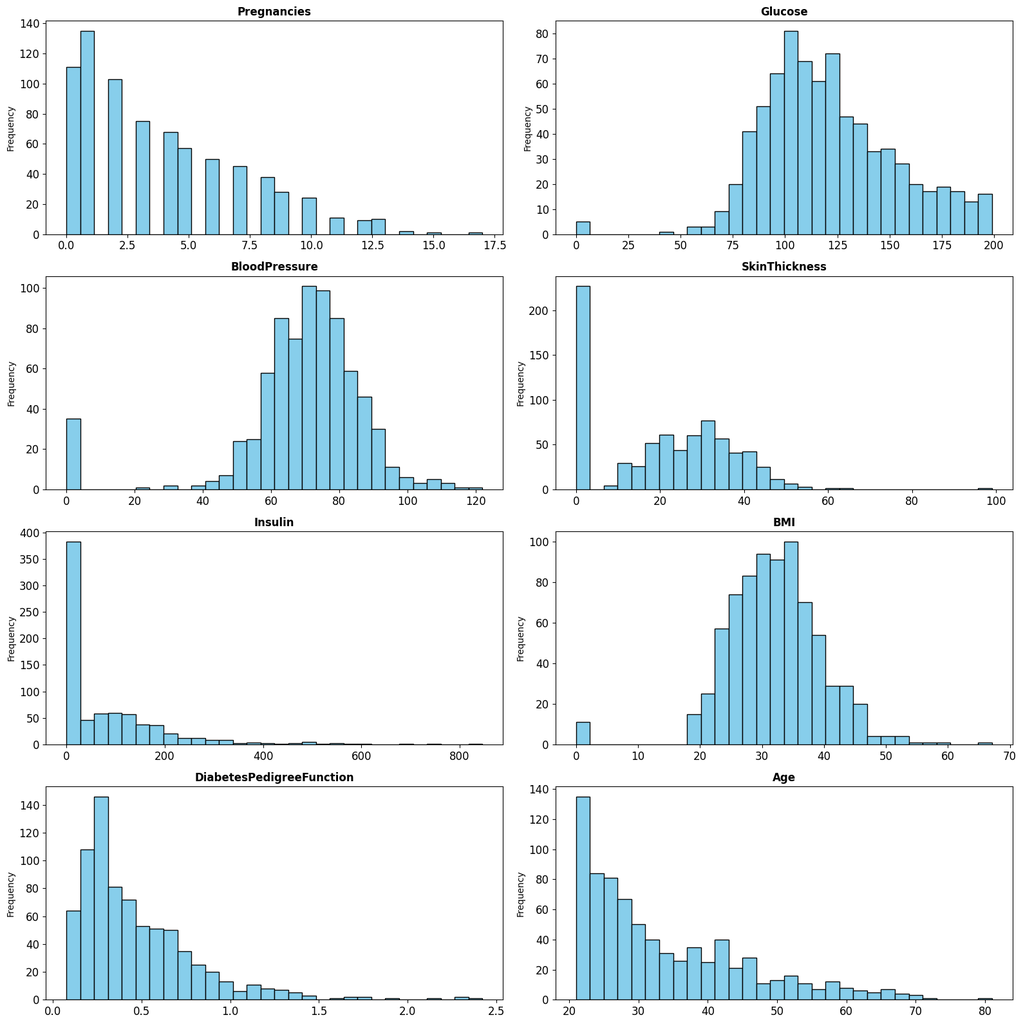

```python
graficos_eda_numericos(df)
```

Al observar las distribuciones, algunos valores parecen no ser realistas o podrían ser datos faltantes representados como ceros. Específicamente:

**SkinThickness** y **Insulin**: Hay una gran cantidad de ceros, lo cual podría indicar datos faltantes. Usaría imputación con mediana, o bien con técnicas avanzadas como KNN para preservar relaciones entre variables.

**BloodPressure**, **BMI**, **Glucose**: Pocos ceros. Estos pueden ser imputados con la mediana de la distribución.

```python
def numericos_objetivo(df, objetivo):
    """
    Esta función grafica la distribución de todas las variables numéricas que existen en un dataframe mediante gráfica de area
    comparando por la variable objetivo
    :param df: (DataFrame) el dataframe del cual se quieren graficar todas las variables categóricas
    :param  objetivo: (DataFrame) el dataframe de la variable objetivo
    :return imagen: una imagen con todas las distribuciones posibles
    """
    numericos = df.select_dtypes('number')
    numericos = numericos.iloc[:, :-1]

    filas = ceil(numericos.shape[1] / 2)
    fig, ax = plt.subplots(nrows=filas, ncols=2, figsize=(16, filas * 4))
    ax = ax.flat

    for posicion, columna in enumerate(numericos.columns):

        tabla_frecuencia = pd.crosstab(df[columna], df[objetivo])

        tabla_frecuencia.plot(kind = 'area', alpha=0.5, stacked=False, color=['PLUM', '#6FD08C'], figsize=(14,20), ax = ax[posicion])

        ax[posicion].set_title(f'{columna}', fontsize=14)
        ax[posicion].set_xlabel(columna, fontsize=12)
        ax[posicion].set_ylabel('Frequency', fontsize=12)
        ax[posicion].legend()

    plt.tight_layout()
    plt.show()
```

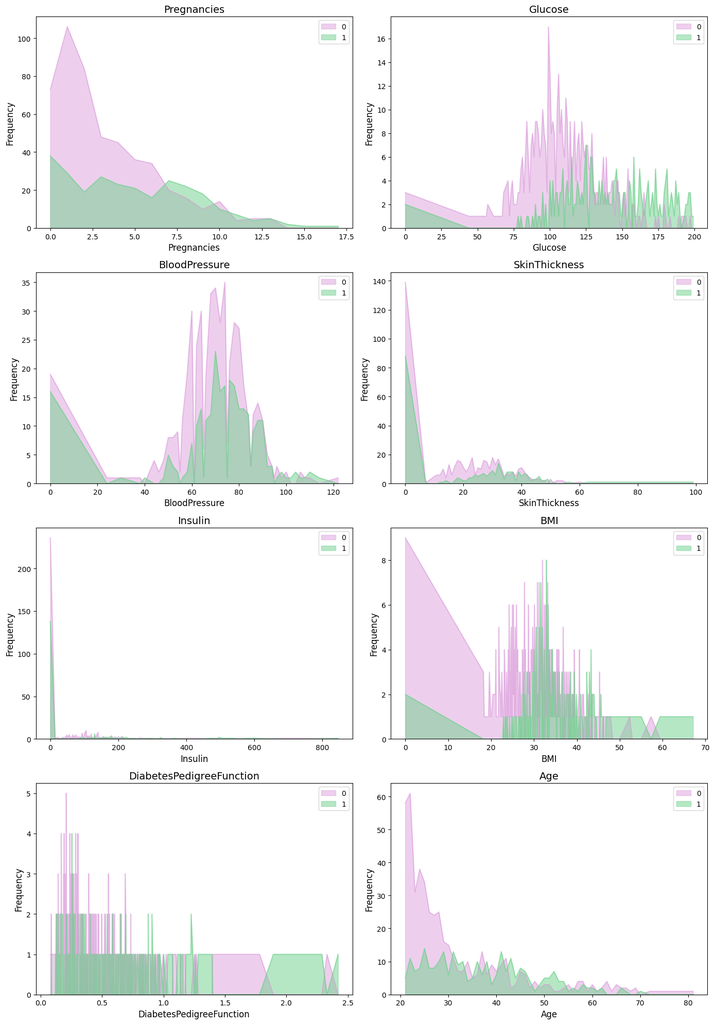

```python
numericos_objetivo(df, 'Outcome')
```

1.3.3. Matriz de Correlación

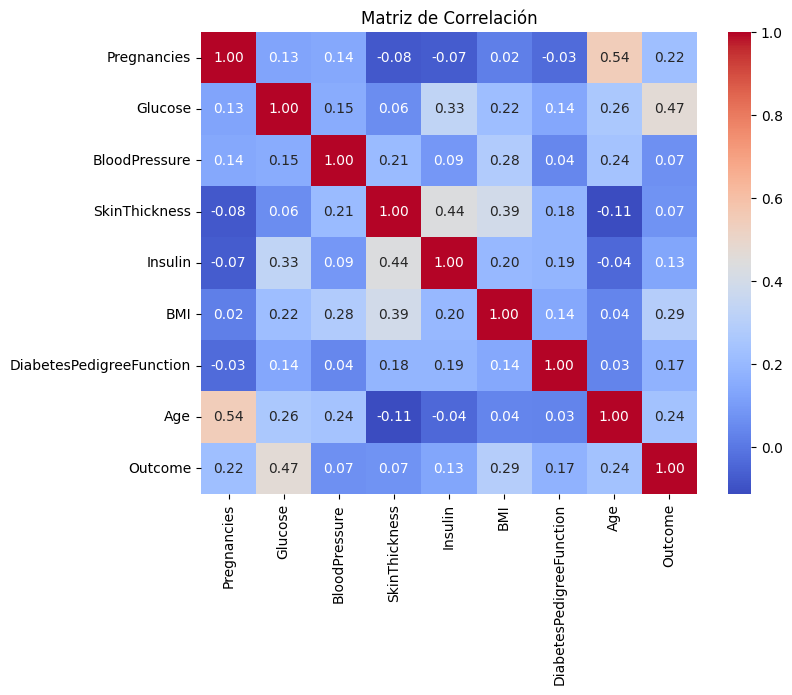

```python
plt.figure(figsize=(8, 6))
sns.heatmap(df.corr(), annot=True, cmap='coolwarm', fmt=".2f")
plt.title('Matriz de Correlación')
plt.show()
```

**Correlación con Outcome**:

**Glucose** (0.47): Es la variable más correlacionada con la presencia de diabetes, lo que indica que los niveles de glucosa en sangre son un factor importante.

**BMI** (0.29): El índice de masa corporal también muestra una correlación positiva con Outcome.

**Age** (0.24): La edad tiene una correlación moderada, lo que sugiere que la diabetes puede estar asociada con el envejecimiento.

**Pregnancies** (0.22): También tiene una correlación positiva, posiblemente debido a cambios metabólicos asociados con múltiples embarazos.

**BloodPressure, SkinThickness, Insulin y DiabetesPedigreeFunction** tienen una correlación débil con Outcome (< 0.2). Estas variables podrían no ser tan relevantes por sí solas, pero podrían ser útiles en combinación con otras variables en un modelo.

**Correlaciones entre variables independientes:**

**Age y Pregnancies** (0.54): Esto tiene sentido, ya que un mayor número de embarazos probablemente esté asociado con una mayor edad.

**SkinThickness y Insulin** (0.44): Esto podría reflejar una relación fisiológica entre el grosor del pliegue cutáneo y los niveles de insulina.

**BMI y SkinThickness** (0.39): Un índice de masa corporal más alto podría estar relacionado con mayores depósitos de grasa subcutánea.

- 1.4. Preprocesamiento de datos:

**Implementación:** Limpiad y preprocesad los datos, incluyendo el tratamiento de valores perdidos y valores atípicos.

```python
#Valores perdidos
print(df.isnull().sum())
```

```
Pregnancies                 0
Glucose                     0
BloodPressure               0
SkinThickness               0
Insulin                     0
BMI                         0
DiabetesPedigreeFunction    0
Age                         0
Outcome                     0
dtype: int64
```

No hay valores nulos como tal en este dataset pero si que hemos visto que hay muchos valores dados como "cero" que no deberían serlo, por lo que se van a imputar.

```python
# Imputación con mediana
columns_to_impute = ['BloodPressure', 'BMI', 'Glucose',]

for column in columns_to_impute:
    median_value = df[column][df[column] != 0].median()  # Calcular mediana excluyendo ceros
    df[column] = df[column].replace(0, median_value)
```

```python
# Imputación con KNN
# Reemplazar ceros con NaN en las columnas a imputar
columns_to_impute = ['Insulin', 'SkinThickness']
df[columns_to_impute] = df[columns_to_impute].replace(0, np.nan)

# Escalar las columnas numéricas
numerical_columns = df.select_dtypes('number').columns
scaler = StandardScaler()
df_scaled = pd.DataFrame(scaler.fit_transform(df[numerical_columns]), columns=numerical_columns)

# Aplicar KNN Imputer solo en las columnas escaladas
knn_imputer = KNNImputer(n_neighbors=5)
df_imputed = knn_imputer.fit_transform(df_scaled)

# Desescalar las columnas imputadas y asignarlas de vuelta
df_scaled_imputed = pd.DataFrame(df_imputed, columns=numerical_columns)
df[numerical_columns] = pd.DataFrame(scaler.inverse_transform(df_imputed), columns=numerical_columns)
```

```python
print("\nDataset information:")
df.head()
```

```
Dataset information:
```

|  | Pregnancies | Glucose | BloodPressure | SkinThickness | Insulin | BMI | DiabetesPedigreeFunction | Age | Outcome |
| --- | --- | --- | --- | --- | --- | --- | --- | --- | --- |
| 0 | 6.0 | 148.0 | 72.0 | 35.0 | 400.2 | 33.6 | 0.627 | 50.0 | 1.0 |
| 1 | 1.0 | 85.0 | 66.0 | 29.0 | 65.2 | 26.6 | 0.351 | 31.0 | 0.0 |
| 2 | 8.0 | 183.0 | 64.0 | 28.8 | 186.0 | 23.3 | 0.672 | 32.0 | 1.0 |
| 3 | 1.0 | 89.0 | 66.0 | 23.0 | 94.0 | 28.1 | 0.167 | 21.0 | 0.0 |
| 4 | 0.0 | 137.0 | 40.0 | 35.0 | 168.0 | 43.1 | 2.288 | 33.0 | 1.0 |

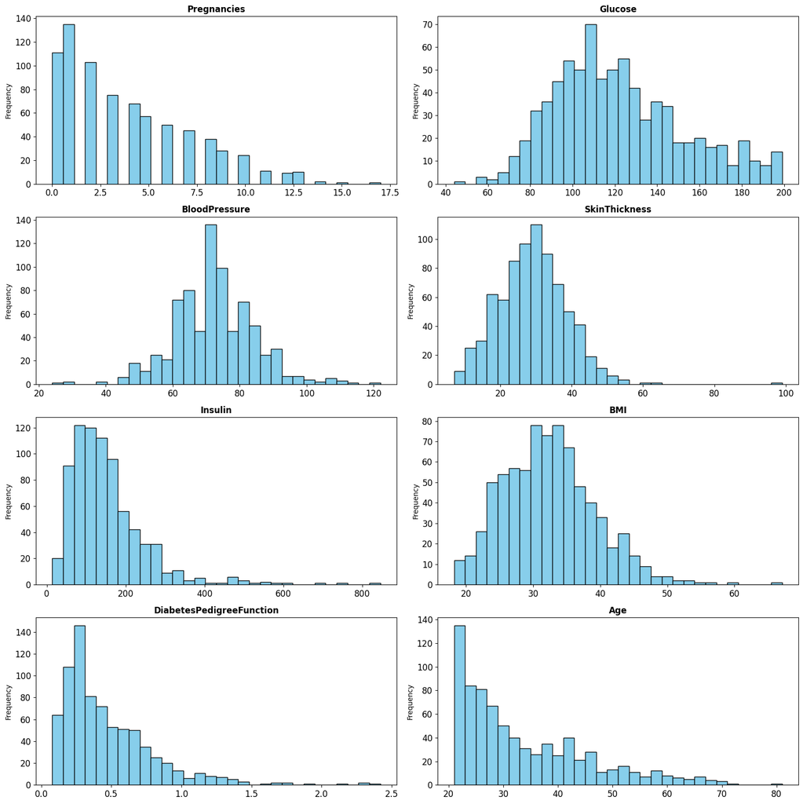

```python
graficos_eda_numericos(df)
```

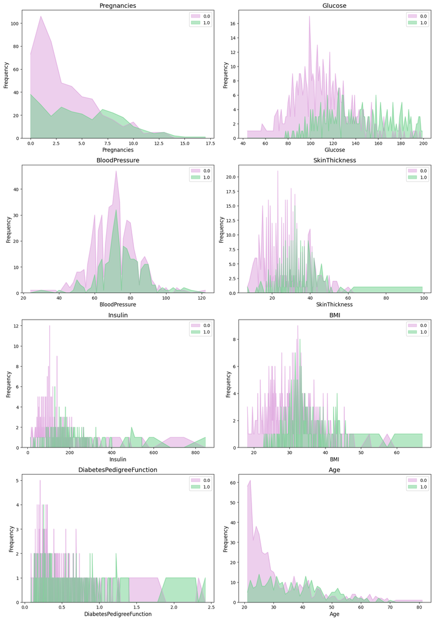

```python
numericos_objetivo(df, 'Outcome')
```

```python
df.shape
```

```
(768, 9)
```

```python
# Detección y tratamiento de los outliers --> Univariante

def remove_outliers_iqr(df, columnas):
    """Elimina los valores atípicos de las columnas especificadas de un DataFrame mediante el método IQR.

    Args:
      df: El DataFrame de entrada.
      columnas: Una lista de nombres de columnas para procesar.

    Devuelve:
      Un nuevo DataFrame con los valores atípicos eliminados.
    """
    df_no_outliers = df.copy()  # Creamos una copia del dataframe

    for col in columnas:
        Q1 = df_no_outliers[col].quantile(0.25)
        Q3 = df_no_outliers[col].quantile(0.75)
        IQR = Q3 - Q1
        lower_bound = Q1 - 1.5 * IQR
        upper_bound = Q3 + 1.5 * IQR
        df_no_outliers = df_no_outliers[(df_no_outliers[col] >= lower_bound) & (df_no_outliers[col] <= upper_bound)]

    return df_no_outliers
```

```python
# Nos quedamos con las columnas numéricas que no son la variable objetivo y eliminamos los outliers
numerical_cols = df.select_dtypes(include=np.number).columns.tolist()
numerical_cols.remove('Outcome')

df_no_outliers = remove_outliers_iqr(df, numerical_cols)

# Update del df original por el que no tiene outliers
df = df_no_outliers

df.describe()
```

|  | Pregnancies | Glucose | BloodPressure | SkinThickness | Insulin | BMI | DiabetesPedigreeFunction | Age | Outcome |
| --- | --- | --- | --- | --- | --- | --- | --- | --- | --- |
| count | 664.000000 | 664.000000 | 664.000000 | 664.000000 | 664.000000 | 664.000000 | 664.000000 | 664.000000 | 664.000000 |
| mean | 3.748494 | 118.513554 | 71.853916 | 28.367771 | 135.322590 | 31.871386 | 0.424087 | 32.207831 | 0.317771 |
| std | 3.225791 | 28.728612 | 10.726043 | 8.721838 | 66.870966 | 6.262652 | 0.245129 | 10.600188 | 0.465961 |
| min | 0.000000 | 44.000000 | 44.000000 | 7.000000 | 15.000000 | 18.200000 | 0.078000 | 21.000000 | 0.000000 |
| 25% | 1.000000 | 99.000000 | 64.000000 | 22.000000 | 84.450000 | 27.375000 | 0.238000 | 24.000000 | 0.000000 |
| 50% | 3.000000 | 114.000000 | 72.000000 | 29.000000 | 125.000000 | 32.000000 | 0.350000 | 29.000000 | 0.000000 |
| 75% | 6.000000 | 135.000000 | 78.000000 | 34.000000 | 175.000000 | 35.900000 | 0.583000 | 39.000000 | 1.000000 |
| max | 13.000000 | 198.000000 | 104.000000 | 52.000000 | 330.000000 | 48.300000 | 1.162000 | 64.000000 | 1.000000 |

```python
# Detección y tratamiento de los outliers --> Multivariante
# Definimos la distancia de mahalanobis
def mahalanobis_distance(data):
    cov_matrix = np.cov(data.T)
    inv_cov_matrix = np.linalg.inv(cov_matrix)
    mean_distr = data.mean(axis=0)
    distances = []
    for i in range(data.shape[0]):
        diff = data[i] - mean_distr
        md = np.sqrt(np.dot(np.dot(diff.T, inv_cov_matrix), diff))
        distances.append(md)
    return np.array(distances)

mahal_distances = mahalanobis_distance(df[numerical_columns].values)
threshold = np.mean(mahal_distances) + 3 * np.std(mahal_distances)
outliers_multivar = df[mahal_distances > threshold]

print(f"Outliers multivariantes detectados: {len(outliers_multivar)}")
```

```
Outliers multivariantes detectados: 6
```

```python
outliers_indices = np.where(mahal_distances > threshold)[0]
df = df.drop(index=outliers_indices)
```

```python
df.head()
```

|  | Pregnancies | Glucose | BloodPressure | SkinThickness | Insulin | BMI | DiabetesPedigreeFunction | Age | Outcome |
| --- | --- | --- | --- | --- | --- | --- | --- | --- | --- |
| 1 | 1.0 | 85.0 | 66.0 | 29.0 | 65.2 | 26.6 | 0.351 | 31.0 | 0.0 |
| 2 | 8.0 | 183.0 | 64.0 | 28.8 | 186.0 | 23.3 | 0.672 | 32.0 | 1.0 |
| 3 | 1.0 | 89.0 | 66.0 | 23.0 | 94.0 | 28.1 | 0.167 | 21.0 | 0.0 |
| 5 | 5.0 | 116.0 | 74.0 | 23.0 | 128.4 | 25.6 | 0.201 | 30.0 | 0.0 |
| 6 | 3.0 | 78.0 | 50.0 | 32.0 | 88.0 | 31.0 | 0.248 | 26.0 | 1.0 |

```python
df.shape
```

```
(658, 9)
```

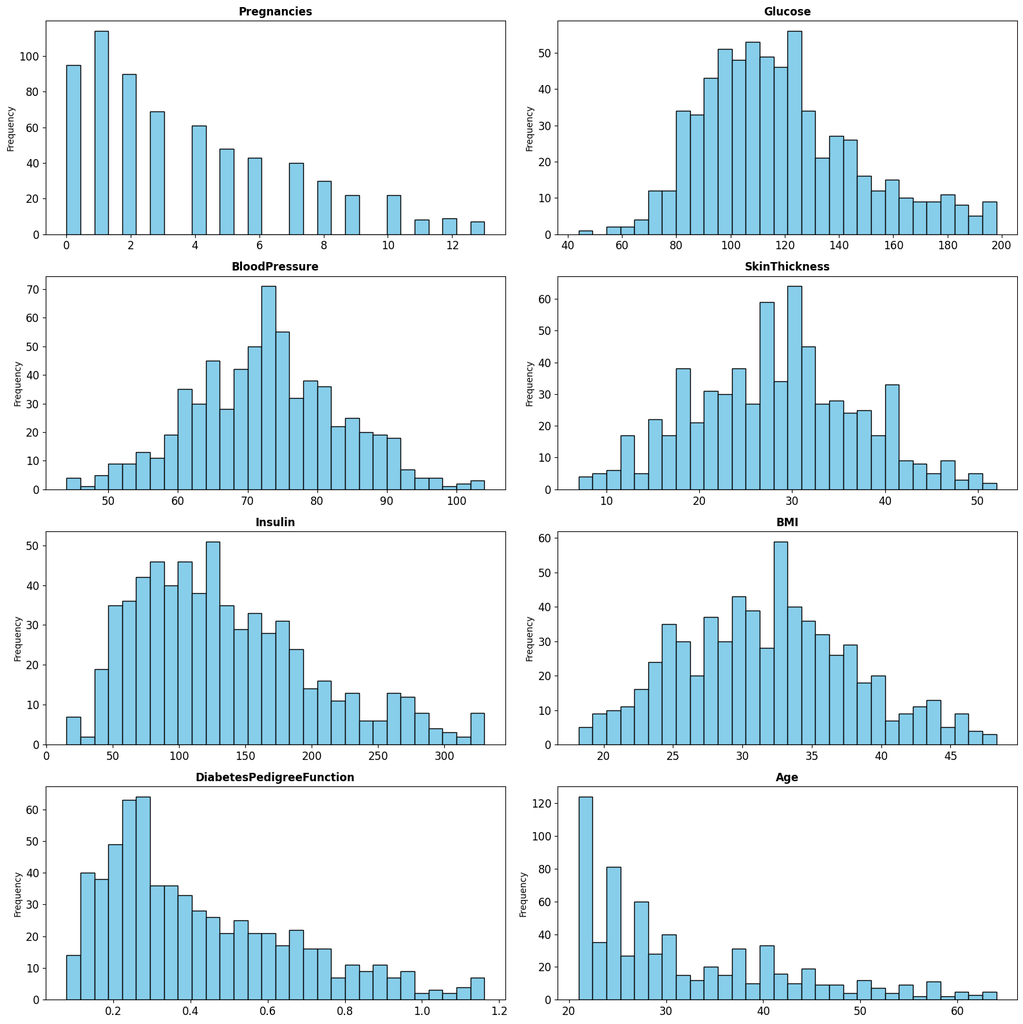

```python
graficos_eda_numericos(df)
```

- 1.5. Balanceo de clases

**Implementación:** Verificación de la distribución de clases.

```
Outcome
0.0    448
1.0    210
Name: count, dtype: int64
```

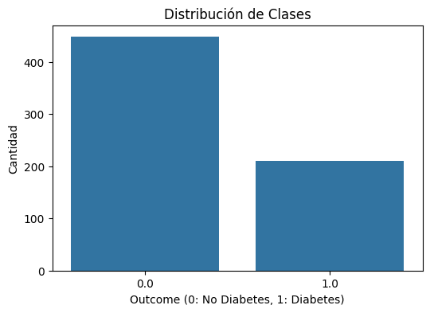

```python
print(df['Outcome'].value_counts())

plt.figure(figsize=(6, 4))
sns.countplot(x='Outcome', data=df)
plt.title('Distribución de Clases')
plt.xlabel('Outcome (0: No Diabetes, 1: Diabetes)')
plt.ylabel('Cantidad')
plt.show()
```

Dado que tenemos previsto utilizar redes neuronales y transferencia de aprendizaje o transfer learning (que puede gestionar bien grandes conjuntos de datos), el mejor método sería una combinación de **SMOTE** y **ADASYN**:

- Primero utiliza **SMOTE**. Ayudará a crear un conjunto de datos equilibrado con muestras sintéticas (random_state=42).
- Después **ADASYN**. Perfeccionará aún más los datos sintéticos, centrándose en las muestras desafiantes (random_state=42).

**Implementación:** Realiza el análisis de balance de clases.

```python
# Separamos características (X) y la variable objetivo (y)
X = df.drop('Outcome', axis=1)
y = df['Outcome']
```

```python
# SMOTE
smote = SMOTE(random_state=42)
X_smote, y_smote = smote.fit_resample(X, y)

# ADASYN
adasyn = ADASYN(random_state=42)
X_resampled, y_resampled = adasyn.fit_resample(X_smote, y_smote)

# Verificamos la distribución de clases
print("Distribución de clases después de SMOTE y ADASYN:")
print(pd.Series(y_resampled).value_counts())
```

```
Distribución de clases después de SMOTE y ADASYN:
Outcome
0.0    448
1.0    448
Name: count, dtype: int64
```

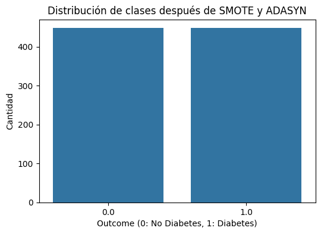

```python
# Visualizamos la nueva distribución de clases
plt.figure(figsize=(6, 4))
sns.countplot(x=y_resampled)
plt.title('Distribución de clases después de SMOTE y ADASYN')
plt.xlabel('Outcome (0: No Diabetes, 1: Diabetes)')
plt.ylabel('Cantidad')
plt.show()
```

**Implementación:** Crea un nuevo DataFrame para los datos remuestreados.

```python
df_resampled = pd.DataFrame(X_resampled, columns=X.columns)
df_resampled['Outcome'] = y_resampled

df_resampled.head()
```

|  | Pregnancies | Glucose | BloodPressure | SkinThickness | Insulin | BMI | DiabetesPedigreeFunction | Age | Outcome |
| --- | --- | --- | --- | --- | --- | --- | --- | --- | --- |
| 0 | 1.0 | 85.0 | 66.0 | 29.0 | 65.2 | 26.6 | 0.351 | 31.0 | 0.0 |
| 1 | 8.0 | 183.0 | 64.0 | 28.8 | 186.0 | 23.3 | 0.672 | 32.0 | 1.0 |
| 2 | 1.0 | 89.0 | 66.0 | 23.0 | 94.0 | 28.1 | 0.167 | 21.0 | 0.0 |
| 3 | 5.0 | 116.0 | 74.0 | 23.0 | 128.4 | 25.6 | 0.201 | 30.0 | 0.0 |
| 4 | 3.0 | 78.0 | 50.0 | 32.0 | 88.0 | 31.0 | 0.248 | 26.0 | 1.0 |

### **2. Reducción de Dimensionalidad (0.5 puntos)**

En esta parte de la PEC, utilizaremos **Análisis de Componentes Principales (PCA)** para mejorar la información de los pacientes diabéticos con el objetivo de facilitar la separación en el modelo de clasificación. Nuestro objetivo es garantizar que el modelo PCA capture patrones útiles para distinguir mejor a los pacientes diabéticos de los no diabéticos.

**Riesgos de Overfitting y Cómo Evitarlos:**

Cuando construimos el modelo PCA solo con pacientes diabéticos, puede existir el riesgo de que los componentes principales capturen patrones específicos de este grupo y no se generalicen bien para los pacientes no diabéticos. Para mitigar este riesgo, seguiremos un enfoque robusto con **validación cruzada**, el cual:

1. **Reduce el sobreajuste**, evaluando la estabilidad de los componentes principales a través de diferentes particiones de datos de pacientes diabéticos.
2. **Garantiza una mejor generalización**, ya que seleccionamos un conjunto estable de componentes mediante la **promediación de las cargas** de los componentes principales a través de los diferentes pliegues (folds) de la validación cruzada.

### **Proceso Recomendado**

1. **Preparación:** Se separan los pacientes diabéticos para el entrenamiento del PCA. Divide los datos diabéticos en entrenamiento/validación (80%) y pruebas (20%), random_state=42.
2. **Normalización y Validación Cruzada para el PCA:** Utilizamos validación cruzada (n_splits=5, shuffle=True, random_state=42) para normalizar los datos y evaluar la consistencia de los componentes principales.
3. **Promediación de los Componentes Principales:** Se promedian las cargas de los componentes principales para obtener un conjunto estable.
4. **Proyección de los Datos Restantes:** Utilizamos los componentes estables para proyectar tanto los datos de test de los pacientes diabéticos como los datos de los pacientes no diabéticos.
5. **Creación del Conjunto de Entrenamiento para Clasificación:** El conjunto de datos proyectado se utiliza como entrada para los modelos de clasificación.

Este enfoque garantiza que el modelo PCA no sobreajuste a los pacientes diabéticos utilizados para construirlo, y nos permite utilizar descriptores coherentes para todo el conjunto de datos. Esto mejora la robustez del modelo de clasificación, minimizando el riesgo de sesgo y mejorando la separación de los pacientes en base a sus características proyectadas.

- 2.1. Preparación.

**Implementación:** Separe los pacientes con diabetes. Divida los datos de pacientes diabéticos en training/testing (80%/20%). Prepare los datos de los pacientes no diabéticos.

```python
# Separar pacientes con y sin diabetes
diabetic_patients = df_resampled[df_resampled['Outcome'] == 1]
non_diabetic_patients = df_resampled[df_resampled['Outcome'] == 0]

# diabéticos
X_diabetic = diabetic_patients.drop('Outcome', axis=1)
y_diabetic = diabetic_patients['Outcome']

X_diabetic_train, X_diabetic_test, y_diabetic_train, y_diabetic_test = train_test_split(
    X_diabetic, y_diabetic, test_size=0.2, random_state=42
)
```

```python
# no diabéticos
X_non_diabetic = non_diabetic_patients.drop(columns=['Outcome'])
y_non_diabetic = non_diabetic_patients['Outcome']
```

- 2.2. Estandarización de los datos

**Implementación:** Escale los datos del entrenamiento y cree el modelo PCA con el 95% de varianza retenida.

```python
# Configuración de validación cruzada
kf = KFold(n_splits=5, shuffle=True, random_state=42)

# Listas para almacenar las cargas de los componentes principales
principal_components_list = []

# Validación cruzada
for train_index, val_index in kf.split(X_diabetic_train):
    X_train_fold, X_val_fold = X_diabetic_train.iloc[train_index], X_diabetic_train.iloc[val_index]

    scaler = StandardScaler()
    X_train_fold_scaled = scaler.fit_transform(X_train_fold)

    pca = PCA(n_components=0.95, random_state=42)
    pca.fit(X_train_fold_scaled)

    principal_components_list.append(pca.components_)

# Promediar las cargas de los componentes principales
principal_components_avg = np.mean(principal_components_list, axis=0)

# Aplicar PCA final usando las cargas promedio
scaler_final = StandardScaler()
X_diabetic_train_scaled = scaler_final.fit_transform(X_diabetic_train)
pca_final = PCA(n_components=principal_components_avg.shape[0], random_state=42)
pca_final.fit(X_diabetic_train_scaled)


# Transformar los datos de entrenamiento con el PCA final
X_diabetic_train_pca = pca_final.transform(X_diabetic_train_scaled)
```

**Implementación:** Realice las gráficas que considere necesarias.

```python
explained_variance_ratio = pca.explained_variance_ratio_
cumulative_variance_ratio = np.cumsum(explained_variance_ratio)
```

```python
cumulative_variance_ratio
```

```
array([0.24900804, 0.46098532, 0.63546159, 0.74858114, 0.85001102,
       0.9156523 , 0.96105676])
```

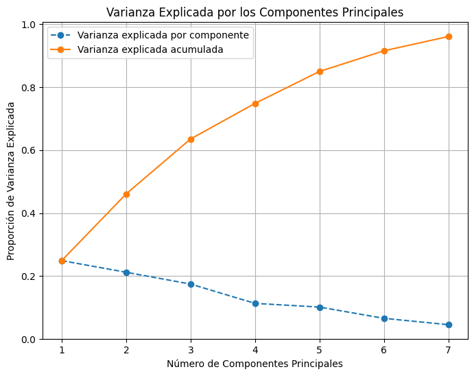

```python
plt.figure(figsize=(8, 6))
plt.plot(range(1, len(explained_variance_ratio) + 1), explained_variance_ratio, marker='o', linestyle='--', label='Varianza explicada por componente')
plt.plot(range(1, len(cumulative_variance_ratio) + 1), cumulative_variance_ratio, marker='o', label='Varianza explicada acumulada')
plt.xlabel('Número de Componentes Principales')
plt.ylabel('Proporción de Varianza Explicada')
plt.title('Varianza Explicada por los Componentes Principales')
plt.legend()
plt.grid(True)
plt.show()
```

El objetivo de esta gráfica esmostrar cuánta varianza de los datos originales es capturada por cada componente principal. Vemos que con 6 PCA se explica más del 90% de la varianza del dataset.

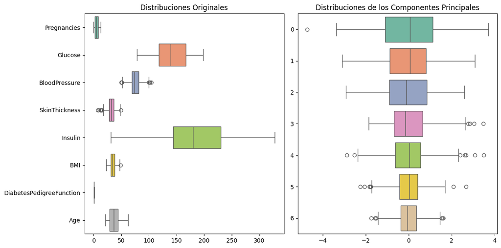

```python
# Distribuciones originales
plt.figure(figsize=(12, 6))
plt.subplot(1, 2, 1)
sns.boxplot(data=X_diabetic_train, orient='h', palette='Set2')
plt.title('Distribuciones Originales')

# Distribuciones proyectadas (Componentes Principales)
plt.subplot(1, 2, 2)
sns.boxplot(data=X_diabetic_train_pca, orient='h', palette='Set2')
plt.title('Distribuciones de los Componentes Principales')

plt.tight_layout()
plt.show()
```

Este gráfico compara las distribuciones de las variables originales y las transformadas en los componentes principales. En las distribuciones originales (izquierda), se pueden notar diferentes escalas y valores extremos (e.g., Insulin). Sin embargo, en los componentes principales (derecha), las distribuciones son más compactas y centradas, lo que refleja cómo PCA transforma los datos para reducir la dimensionalidad mientras captura la varianza.

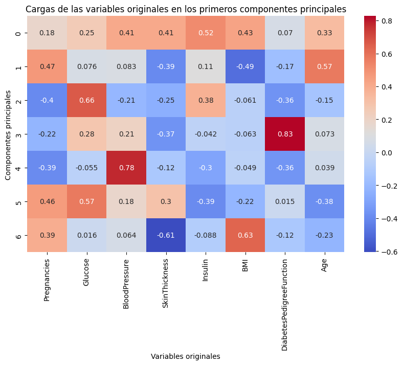

```python
# Cargar de las variables originales en los primeros componentes principales
plt.figure(figsize=(10, 6))
components = pd.DataFrame(pca_final.components_, columns=X_diabetic_train.columns)
sns.heatmap(components.iloc[:7], cmap='coolwarm', annot=True, xticklabels=X_diabetic_train.columns)
plt.title('Cargas de las variables originales en los primeros componentes principales')
plt.xlabel('Variables originales')
plt.ylabel('Componentes principales')
plt.show()
```

Este heatmap muestra cómo cada variable original contribuye a los primeros componentes principales.

**Glucose, BMI, SkinThickness y Age** son variables que contribuyen significativamente a los primeros componentes, lo que las hace altamente relevantes para el análisis.

- 2.4. Proyección de los Datos Restantes

En este punto, ya hemos construido el modelo PCA utilizando solo los datos de los pacientes diagnosticados con diabetes. Ahora, para poder comparar el rendimiento de nuestros clasificadores de manera consistente, necesitamos proyectar **todas** las muestras. Tanto los datos escalados de los pacientes con diabetes (restante 20%) como los de los pacientes sin diabetes, sobre este mismo modelo PCA.

##### **¿Por qué proyectar todos los datos sobre el mismo modelo PCA?**

1. **Consistencia de los descriptores**:
   - Al proyectar todos los datos sobre el mismo modelo PCA, obtenemos un conjunto de descriptores uniformes (los componentes principales) para todos los pacientes, independientemente de su diagnóstico. Esto es clave para que los clasificadores trabajen con las mismas variables de entrada.
2. **Reducción de la dimensionalidad**:
   - Utilizar los componentes principales como variables de entrada reduce el número de dimensiones, lo que facilita el entrenamiento de los modelos y reduce el riesgo de overfitting.
3. **Mejora de la generalización**:
   - Al usar descriptores PCA, que son las combinaciones lineales de las variables originales más informativas, se mejora la capacidad del modelo para generalizar a nuevos datos.

**Implementación:** Proyecte los datos restantes en el modelo PCA creado anteriormente.

```python
# Escalamos los datos restantes usando el mismo StandardScaler
X_diabetic_test_scaled = scaler_final.transform(X_diabetic_test)
X_non_diabetic_scaled = scaler_final.transform(X_non_diabetic)

# Proyectamos los datos restantes sobre el modelo PCA
X_diabetic_test_pca = pca_final.transform(X_diabetic_test_scaled)
X_non_diabetic_pca = pca_final.transform(X_non_diabetic_scaled)

print(f"Dimensiones proyectadas (test diabéticos): {X_diabetic_test_pca.shape}")
print(f"Dimensiones proyectadas (no diabéticos): {X_non_diabetic_pca.shape}")
```

```
Dimensiones proyectadas (test diabéticos): (90, 7)
Dimensiones proyectadas (no diabéticos): (448, 7)
```

```python
# Combinamos los datos proyectados
X_combined_pca = np.vstack((X_diabetic_train_pca, X_diabetic_test_pca, X_non_diabetic_pca))
y_combined = np.hstack((y_diabetic_train, y_diabetic_test, y_non_diabetic))

# Verificamos las dimensiones combinadas
print(f"Dimensiones del conjunto combinado (X): {X_combined_pca.shape}")
print(f"Dimensiones del conjunto combinado (y): {y_combined.shape}")
```

```
Dimensiones del conjunto combinado (X): (896, 7)
Dimensiones del conjunto combinado (y): (896,)
```

**Implementación:** Realice las gráficas que considere necesarias.

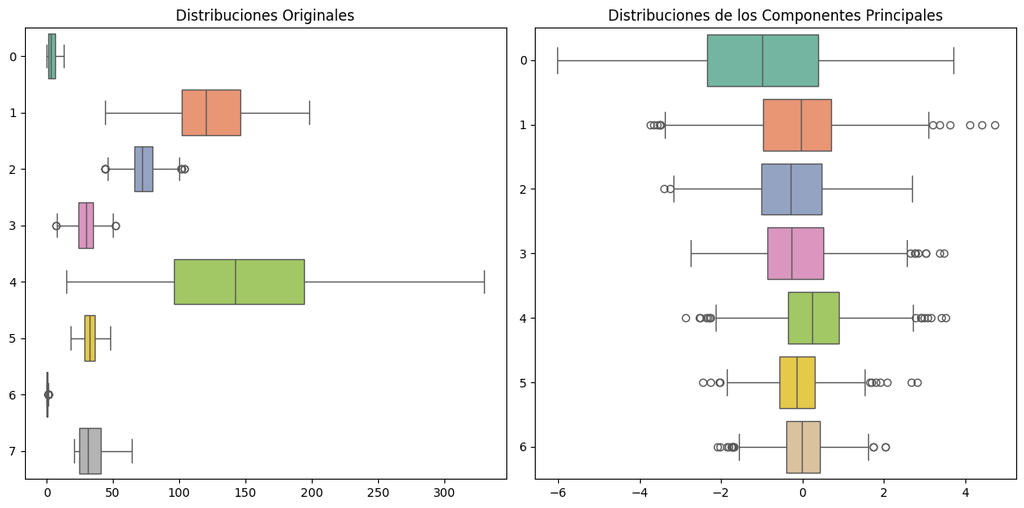

```python
# Graficar distribuciones originales y componentes principales
plt.figure(figsize=(12, 6))

plt.subplot(1, 2, 1)
sns.boxplot(data=np.vstack((X_diabetic_train, X_diabetic_test, X_non_diabetic)), orient='h', palette='Set2')
plt.title('Distribuciones Originales')

plt.subplot(1, 2, 2)
sns.boxplot(data=X_combined_pca, orient='h', palette='Set2')
plt.title('Distribuciones de los Componentes Principales')

plt.tight_layout()
plt.show()
```

Al igual que en el caso anterior, las variables originales tienen diferentes rangos y escalas y, sin embargo, los componentes principales están normalizados y la dispersión es más homogénea.

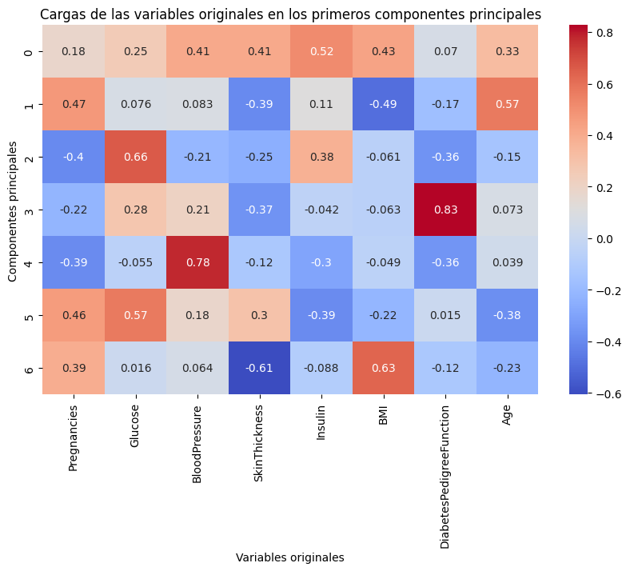

```python
# Heatmap de las cargas de las variables originales en los componentes principales
plt.figure(figsize=(10, 6))
components = pd.DataFrame(pca_final.components_, columns=X_diabetic_train.columns)
sns.heatmap(components.iloc[:7], cmap='coolwarm', annot=True, xticklabels=X_diabetic_train.columns)
plt.title('Cargas de las variables originales en los primeros componentes principales')
plt.xlabel('Variables originales')
plt.ylabel('Componentes principales')
plt.show()
```

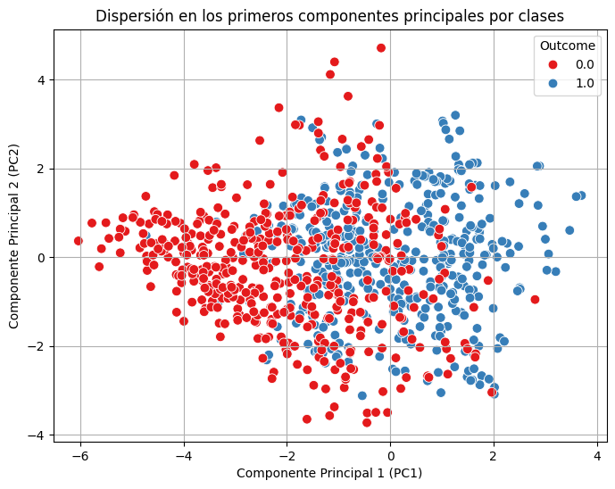

```python
# Graficar dispersión por clases
plt.figure(figsize=(8, 6))
sns.scatterplot(
    x=X_combined_pca[:, 0],
    y=X_combined_pca[:, 1],
    hue=y_combined,
    palette='Set1',
    s=60
)
plt.title('Dispersión en los primeros componentes principales por clases')
plt.xlabel('Componente Principal 1 (PC1)')
plt.ylabel('Componente Principal 2 (PC2)')
plt.legend(title='Outcome', loc='best')
plt.grid()
plt.show()
```

En esta gráfica, aunque hay cierto solapamiento entre las clases, se puede observar una separación moderada entre pacientes diabéticos y no diabéticos.

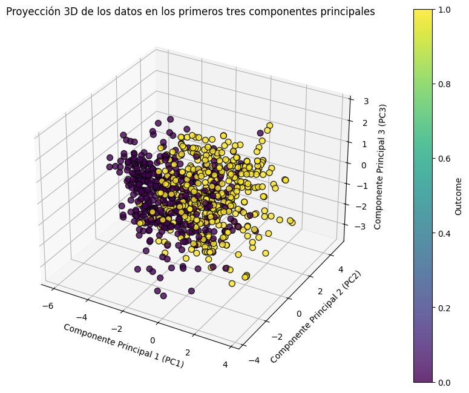

```python
# Crear la figura en 3D
fig = plt.figure(figsize=(10, 8))
ax = fig.add_subplot(111, projection='3d')

# Proyección en los primeros tres componentes principales
sc = ax.scatter(
    X_combined_pca[:, 0],  # PC1
    X_combined_pca[:, 1],  # PC2
    X_combined_pca[:, 2],  # PC3
    c=y_combined,          # Clases (Outcome)
    cmap='viridis',        # Colormap
    edgecolor='k',
    s=50,
    alpha=0.8
)

# Etiquetas de los ejes
ax.set_xlabel('Componente Principal 1 (PC1)')
ax.set_ylabel('Componente Principal 2 (PC2)')
ax.set_zlabel('Componente Principal 3 (PC3)')
ax.set_title('Proyección 3D de los datos en los primeros tres componentes principales')

# Agregar barra de color
cbar = fig.colorbar(sc, ax=ax, pad=0.1)
cbar.set_label('Outcome')

plt.show()
```

En esta gráfica se puede ver que la separación de las clases es más visible que en 2D, aunque sigue habiendo solapamiento.

- 2.5. Sobre el almacenamiento de los componentes principales

Al trabajar con modelos de PCA utilizando la librería `scikit-learn`, es importante entender que el objeto del PCA (`pca_final`) **no guarda automáticamente los componentes principales asociados a las muestras transformadas**. El PCA solo mantiene los componentes del modelo (es decir, las combinaciones lineales de las variables originales) y la información de la varianza explicada.

Por ello, si deseáis conservar los **valores de los componentes principales (scores)** asociados a cada muestra transformada para su uso futuro, debéis hacerlo **manualmente**, creando un DataFrame separado. Esto os permitirá:

1. **Reutilizar los datos**: Podréis cargarlos directamente en el futuro sin tener que repetir el cálculo del PCA.
2. **Asegurar la consistencia**: Evitad diferencias si el conjunto de datos original cambia o si se añaden nuevas muestras.
3. **Preparar los datos para el análisis**: Podéis combinar los scores con otras variables o utilizarlos directamente en modelos de clasificación.

Consideraciones finales:

- Recordad que este proceso debe repetirse para cualquier conjunto de datos que deseéis proyectar en el modelo PCA (diabetic_test_data, non_diabetic_data).
- Esta separación permite mantener el modelo PCA enfocado únicamente en transformaciones y conservar los scores como datos procesados.

Esta particularidad puede parecer poco intuitiva al principio, pero asegura que el modelo se mantenga modular y fácil de utilizar para otras transformaciones.

**Implementación:** Aplica el modelo previamente creado. Etiqueta los conjuntos de datos en diferentes dataframes manteniendo las muestras originales. Los nombres para los dataframes son: * "diabetic_train_pca": Conjunto de entrenamiento para pacientes diabéticos. * "diabetic_test_pca": Conjunto de test para pacientes diabéticos. * "non_diabetic_pca": Conjunto de pacientes no diabéticos.

Cada DataFrame tiene: * Una columna para cada componente principal ("PC1", "PC2", ..., "PCn"). * Una columna "Outcome" para identificar si son muestras de diabéticos o no.

```python
pca_columns = [f"PC{i+1}" for i in range(X_diabetic_train_pca.shape[1])]

# DataFrame para pacientes diabéticos (entrenamiento)
diabetic_train_pca = pd.DataFrame(X_diabetic_train_pca, columns=pca_columns)
diabetic_train_pca['Outcome'] = y_diabetic_train.values

# DataFrame para pacientes diabéticos (test)
diabetic_test_pca = pd.DataFrame(X_diabetic_test_pca, columns=pca_columns)
diabetic_test_pca['Outcome'] = y_diabetic_test.values

# DataFrame para pacientes no diabéticos
non_diabetic_pca = pd.DataFrame(X_non_diabetic_pca, columns=pca_columns)
non_diabetic_pca['Outcome'] = y_non_diabetic.values

# DataFrame combinado con todo para PCA
combined_pca = pd.DataFrame(X_combined_pca, columns=pca_columns)
combined_pca['Outcome'] = y_combined

# Dimensiones de los DataFrames
print("Dimensiones de los DataFrames creados:")
print(f"diabetic_train_pca: {diabetic_train_pca.shape}")
print(f"diabetic_test_pca: {diabetic_test_pca.shape}")
print(f"non_diabetic_pca: {non_diabetic_pca.shape}")
print(f"Dimensiones del DataFrame combinado: {combined_pca.shape}")
```

```
Dimensiones de los DataFrames creados:
diabetic_train_pca: (358, 8)
diabetic_test_pca: (90, 8)
non_diabetic_pca: (448, 8)
Dimensiones del DataFrame combinado: (896, 8)
```

### 3. Entrenamiento y Evaluación de Modelos Base (2.5 puntos)

Se formarán cuatro modelos diferentes:

- 1. Regresión Logística
- 2. Árbol de Decisión
- 3. Bosque Aleatorio (Random Forest)
- 4. SVM

y cada modelo será entrenado utilizando los dos grupos de:

- Las características originales
- Las características transformadas de PCA.

##### 3.1 Entrenamiento

3.1.1. Características originales

Pasos a seguir para las entradas de las características originales:

- 1. Reúne las características originales en un solo dataframe llamado X y otro llamado y para la salida u outcome.
- 2. Asigna las etiquetas de clase: Asigna 1 para muestras diabéticas y 0 para muestras no diabéticas.
- 3. Divide los datos: Asegúrate de dividir el conjunto de datos combinado en conjuntos de entrenamiento (80%) y prueba si no lo has hecho ya. Esto evita la fuga de información de las pruebas al entrenamiento.
- 4. Entrenamiento y evaluación de modelos de clasificación: Utiliza el conjunto de datos para entrenar modelos que puedan separar las clases diabéticas y no diabéticas.

**Implementación:** Para las características originales, prepara la entrada X y salida/outcome y para los clasificadores. Divide el conjunto de datos en 80%-20% para entrenamiento y prueba.

```python
X_original = df_resampled.drop(columns=['Outcome'])
y_original = df_resampled['Outcome']

X_train_original, X_test_original, y_train_original, y_test_original = train_test_split(
    X_original, y_original, test_size=0.2, random_state=42, stratify=y_original
)

scaler = StandardScaler()
X_train_original_scaled = scaler.fit_transform(X_train_original)
X_test_original_scaled = scaler.transform(X_test_original)

X_train_original_scaled = pd.DataFrame(X_train_original_scaled, columns=X_train_original.columns)
X_test_original_scaled = pd.DataFrame(X_test_original_scaled, columns=X_test_original.columns)
```

3.1.2. Entradas de los componentes principales

Este es el momento en el que utilizarás los componentes principales que has almacenado anteriormente de PCA. Pasos a seguir para las entradas de los componentes principales:

- 1. Combina los componentes principales diabéticos y no diabéticos: Combina los componentes principales de los datos diabéticos (entrenamiento y prueba) y no diabéticos en un único conjunto de datos para la clasificación.
- 2. Asigna las etiquetas de clase: Asigna 1 para muestras diabéticas y 0 para muestras no diabéticas.
- 3. Divide los datos combinados: Asegúrate de dividir el conjunto de datos combinado en conjuntos de entrenamiento (80%) y prueba si no lo has hecho ya. Esto evita la fuga de información de las pruebas al entrenamiento.
- 4. Entrenamiento y evaluación de modelos de clasificación: Utiliza el conjunto de datos para entrenar modelos que puedan separar eficazmente las clases diabéticas y no diabéticas.

**Implementación:** Para las características transformadas de PCA, prepara la entrada X y la salida/outcome y para los clasificadores. Divide el conjunto de datos en un 80% para entrenamiento y un 20% para prueba.

```python
X_pca = combined_pca.drop(columns=['Outcome'])
y_pca = combined_pca['Outcome']

X_train_pca, X_test_pca, y_train_pca, y_test_pca = train_test_split(
    X_pca, y_pca, test_size=0.2, random_state=42, stratify=y_pca
)
```

- 3.2. Entrenamiento de los modelos de clasificación con las variables originales

**Implementación:** Entrena modelos base con las variables originales como descriptores y evalúa los modelos utilizando métricas de exactitud, sensibilidad, especificidad, ROC-AUC y análisis de la matriz de confusión.

```python
models = {
    "Logistic Regression": LogisticRegression(random_state=42),
    "Decision Tree": DecisionTreeClassifier(random_state=42),
    "Random Forest": RandomForestClassifier(random_state=42),
    "SVM": SVC(probability=True, random_state=42)
}
```

```python
for model_name, model in models.items():
    print(f"\n{model_name}\n")
    model.fit(X_train_original_scaled, y_train_original)  # Entrenamiento
    y_pred = model.predict(X_test_original_scaled)        # Predicciones
    y_prob = model.predict_proba(X_test_original)[:, 1]  # Probabilidades (para ROC-AUC)

    # Métricas
    print(classification_report(y_test_original, y_pred))
    print(f"\nROC-AUC: {roc_auc_score(y_test_original, y_prob):.4f}")
    print(f"\nMatriz de Confusión:\n{confusion_matrix(y_test_original, y_pred)}")
```

```
Logistic Regression

              precision    recall  f1-score   support

         0.0       0.82      0.78      0.80        90
         1.0       0.79      0.83      0.81        90

    accuracy                           0.81       180
   macro avg       0.81      0.81      0.81       180
weighted avg       0.81      0.81      0.81       180


ROC-AUC: 0.5000

Matriz de Confusión:
[[70 20]
 [15 75]]

Decision Tree

              precision    recall  f1-score   support

         0.0       0.81      0.72      0.76        90
         1.0       0.75      0.83      0.79        90

    accuracy                           0.78       180
   macro avg       0.78      0.78      0.78       180
weighted avg       0.78      0.78      0.78       180


ROC-AUC: 0.5000

Matriz de Confusión:
[[65 25]
 [15 75]]

Random Forest

              precision    recall  f1-score   support

```

[output cut: 16 more lines]

```
              precision    recall  f1-score   support

         0.0       0.86      0.80      0.83        90
         1.0       0.81      0.87      0.84        90

    accuracy                           0.83       180
   macro avg       0.83      0.83      0.83       180
weighted avg       0.83      0.83      0.83       180


ROC-AUC: 0.5000

Matriz de Confusión:
[[72 18]
 [12 78]]
```

- 3.3. Entrenamiento de los modelos de clasificación con las variables transformadas por los componentes principales (PCs)

**Implementación:** Entrena modelos base con los componentes principales (PCs) como descriptores y evalúa los modelos utilizando métricas de exactitud, sensibilidad, especificidad, ROC-AUC y análisis de la matriz de confusión.

```python
for model_name, model in models.items():
    print(f"\n{model_name} con PCA\n")
    model.fit(X_train_pca, y_train_pca)  # Entrenamiento
    y_pred = model.predict(X_test_pca)  # Predicciones
    y_prob = model.predict_proba(X_test_pca)[:, 1]  # Probabilidades (para ROC-AUC)

    # Métricas
    print(classification_report(y_test_pca, y_pred))
    print(f"\nROC-AUC: {roc_auc_score(y_test_pca, y_prob):.4f}")
    print(f"\nMatriz de Confusión:\n{confusion_matrix(y_test_pca, y_pred)}")
```

```
Logistic Regression con PCA

              precision    recall  f1-score   support

         0.0       0.89      0.78      0.83        90
         1.0       0.80      0.90      0.85        90

    accuracy                           0.84       180
   macro avg       0.84      0.84      0.84       180
weighted avg       0.84      0.84      0.84       180


ROC-AUC: 0.9135

Matriz de Confusión:
[[70 20]
 [ 9 81]]

Decision Tree con PCA

              precision    recall  f1-score   support

         0.0       0.85      0.70      0.77        90
         1.0       0.75      0.88      0.81        90

    accuracy                           0.79       180
   macro avg       0.80      0.79      0.79       180
weighted avg       0.80      0.79      0.79       180


ROC-AUC: 0.7889

Matriz de Confusión:
[[63 27]
 [11 79]]

Random Forest con PCA

              precision    recall  f1-score   support

```

[output cut: 16 more lines]

```
              precision    recall  f1-score   support

         0.0       0.91      0.78      0.84        90
         1.0       0.81      0.92      0.86        90

    accuracy                           0.85       180
   macro avg       0.86      0.85      0.85       180
weighted avg       0.86      0.85      0.85       180


ROC-AUC: 0.9116

Matriz de Confusión:
[[70 20]
 [ 7 83]]
```

- 3.4 Análisis de resultados

**Análisis:** Analice los resultados utilizando las variables originales como entradas a las herramientas de clasificación y los resultados utilizando los principales componentes o variables latentes como entradas a las mismas herramientas de clasificación.

**DATOS ORIGINALES**

- **Logistic Regression**:
  - **Exactitud:** 81%
  - **ROC-AUC:** 0.5000 (indica que no hay capacidad de separar las clases en términos probabilísticos; podría ser un problema en el cálculo de las probabilidades).
  - **Análisis:** La Regresión Logística muestra un desempeño aceptable en términos de precisión, recall y f1-score para ambas clases. La matriz de confusión indica que predice correctamente 70 pacientes no diabéticos y 75 pacientes diabéticos, pero confunde 20 y 15 casos, respectivamente. Sin embargo, el bajo ROC-AUC (0.5000) implica que el modelo no está generando probabilidades de separación confiables.
- **Decision Tree:**
  - **Exactitud:** 78%
  - **ROC-AUC:** 0.5000 (sin capacidad de separar probabilísticamente).
  - **Análisis:** El Árbol de Decisión presenta un peor desempeño general comparado con otros modelos. Tiende a cometer más errores al clasificar pacientes no diabéticos (confunde 25 casos como diabéticos). El recall es mejor para la clase 1 (diabéticos), con 83%, pero compromete la precisión.
- **Random Forest:**
  - **Exactitud:** 85% (mejor entre los modelos).
  - **ROC-AUC:** 0.5057.
  - **Análisis:** Este modelo logra un equilibrio destacado entre las métricas de precisión, recall y f1-score para ambas clases. Su capacidad para identificar correctamente pacientes no diabéticos (74 correctos) y diabéticos (79 correctos) lo convierte en el mejor clasificador entre los modelos evaluados con variables originales. Aunque el ROC-AUC aún no es ideal, las métricas indican que Random Forest maneja bien la complejidad de los datos.
- **Support Vector Machine (SVM):**
  - **Exactitud:** 83%.
  - **ROC-AUC:** 0.5000.
  - **Análisis:** SVM presenta un buen desempeño general, destacando con un f1-score más equilibrado entre las clases (83% y 84%). Confunde 18 pacientes no diabéticos como diabéticos y 12 pacientes diabéticos como no diabéticos, lo que lo hace más equilibrado que Decision Tree en términos de errores. Sin embargo, su ROC-AUC es bajo, lo que indica limitaciones en la probabilidad de separación.
- **Conclusiones**
  1. El **Random Forest** es el mejor clasificador en este caso, destacándose en precisión, recall y exactitud general.
  2. Las variables originales permiten un desempeño razonable en todos los modelos, aunque el ROC-AUC es bajo, lo que indica problemas para generar probabilidades confiables.

**DATOS PCA**

**COMPARATIVA DE LOS RESULTADOS**

| **Modelo** | **Exactitud (Original)** | **Exactitud (PCA)** | **ROC-AUC (Original)** | **ROC-AUC (PCA)** | **Observaciones** |
| --- | --- | --- | --- | --- | --- |
| **Logistic Regression** | 81% | 84% | 0.5000 | 0.9135 | Mejora significativa con PCA, especialmente en la capacidad probabilística. |
| **Decision Tree** | 78% | 79% | 0.5000 | 0.7889 | Ligeramente mejor con PCA, pero sigue siendo el modelo más débil en ambos casos. |
| **Random Forest** | 85% | 88% | 0.5057 | 0.9489 | Mejor modelo en ambos casos; mejora notable con PCA en todas las métricas. |
| **SVM** | 83% | 85% | 0.5000 | 0.9116 | Beneficiado por PCA; mayor capacidad de separación probabilística y exactitud. |

**Resumen**

- **Mejor Exactitud y ROC-AUC (Original):**
  - **Random Forest** es el mejor modelo con las características originales, alcanzando un 85% de exactitud y un ROC-AUC de 0.5057.
- **Mejor Exactitud y ROC-AUC (PCA):**
  - **Random Forest** también lidera con PCA, alcanzando un 88% de exactitud y un ROC-AUC sobresaliente de 0.9489.
- **Impacto de PCA:**
  - Todos los modelos mejoraron con PCA, excepto **Decision Tree**, cuyo desempeño fue similar.
  - La **Regresión Logística** y **SVM** se beneficiaron especialmente de la reducción de dimensionalidad, mostrando un aumento notable en ROC-AUC.
- **Decision Tree:**
  - Es el modelo con el peor desempeño en ambas configuraciones, mostrando limitaciones en la separación entre clases.

### **4. Técnicas Avanzadas de Ensemble (2.5 puntos)**

- 4.1. Implemente y evalúe técnicas de ensemble como Bagging, Boosting, Stacking y Cascading utilizando las variables originales.
- 4.2. Repita la implementación con los componentes principales como descriptores.
- 4.3. Compare el rendimiento de cada método y analice los resultados.

Para aplicar el ensemble learning, proponemos seguir los siguientes pasos:

**1. Clase `CascadingClassifier`**

###### **Propósito:**

- Implementa una técnica personalizada de aprendizaje en ensamblado donde las predicciones de un primer modelo (`base_model1`) se añaden como características adicionales a los datos de entrada para un segundo modelo (`base_model2`).

###### **Componentes clave:**

- **Método `__init__`:**
  - Inicializa el clasificador con dos modelos base.
- **Método `fit`:**
  - Entrena el `base_model1` con las características de entrada (`X`) y las etiquetas (`y`).
  - Genera las predicciones del `base_model1` y las añade como una nueva columna a las características de entrada.
  - Entrena el `base_model2` con este conjunto de datos aumentado.
- **Método `predict`:**
  - Utiliza el `base_model1` entrenado para predecir las etiquetas de los datos de entrada.
  - Aumenta las características de entrada con estas predicciones y las pasa al `base_model2` para obtener las predicciones finales.
- **Método `predict_proba`:**
  - Similar a `predict`, pero devuelve las probabilidades de clase para los datos de entrada.

###### **Librerías y técnicas clave:**

- **`np.hstack`:** Combina arrays por columnas para añadir las predicciones como características.
- **`BaseEstimator` y `ClassifierMixin`:** Garantizan la compatibilidad con los pipelines y métodos de evaluación de Scikit-learn.

**2. Función `evaluate_ensemble`**

###### **Propósito:**

- Evalúa el rendimiento de los modelos ensemble utilizando métricas como el accuracy, la sensibilidad, la especificidad y el ROC-AUC. También genera una matriz de confusión y la curva ROC.

###### **Visualización:**

- Utiliza `RocCurveDisplay` para trazar la curva ROC.
- Mejora la interpretabilidad

**Implementación:** Aplica los pasos anteriormente descritos para obtener los modelos y realizar el testing de las técnicas de Bagging, Boosting, Stacking y Cascading, tanto para las características originales como para los componentes principales:

```python
# Función Ensemble

def evaluate_ensemble(model, X_test, y_test, model_name="Ensemble Model"):
    """
    Evalúa un modelo ensemble y genera métricas de rendimiento.

    :param model: Modelo a evaluar
    :param X_test: Datos de prueba (características)
    :param y_test: Datos de prueba (etiquetas)
    :param model_name: Nombre del modelo para imprimir en los resultados
    :return: Diccionario con las métricas calculadas
    """
    # Predicciones del modelo
    y_pred = model.predict(X_test)
    y_prob = model.predict_proba(X_test)[:, 1]  # Probabilidades de la clase positiva

    # Calcular la matriz de confusión
    cm = confusion_matrix(y_test, y_pred)
    tn, fp, fn, tp = cm.ravel()  # True Negatives, False Positives, False Negatives, True Positives

    # Calcular métricas
    accuracy = (tp + tn) / (tp + tn + fp + fn)
    sensitivity = tp / (tp + fn)  # Recall para la clase positiva
    specificity = tn / (tn + fp)  # Recall para la clase negativa
    roc_auc = roc_auc_score(y_test, y_prob)

    # Mostrar resultados
    print(f"\nEvaluación del modelo: {model_name}")
    print(f"Accuracy: {accuracy:.4f}")
    print(f"Sensitivity (Recall para clase positiva): {sensitivity:.4f}")
    print(f"Specificity (Recall para clase negativa): {specificity:.4f}")
    print(f"ROC-AUC: {roc_auc:.4f}")
    print("Matriz de Confusión:")
    print(cm)
    print("\nReporte de Clasificación:")
    print(classification_report(y_test, y_pred))

    # Curva ROC
    RocCurveDisplay.from_predictions(y_test, y_prob, name=model_name)
```

**CARACTERISTICAS ORIGINALES**

**1.** **Bagging**

```python
bagging_model = BaggingClassifier(
    estimator=DecisionTreeClassifier(random_state=42),
    n_estimators=50,
    random_state=42
)
bagging_model.fit(X_train_original_scaled, y_train_original)

# Predicciones
y_pred_bagging = bagging_model.predict(X_test_original_scaled)
y_prob_bagging = bagging_model.predict_proba(X_test_original_scaled)[:, 1]
```

```
Evaluación del modelo: Bagging
Accuracy: 0.8611
Sensitivity (Recall para clase positiva): 0.8778
Specificity (Recall para clase negativa): 0.8444
ROC-AUC: 0.9111
Matriz de Confusión:
[[76 14]
 [11 79]]

Reporte de Clasificación:
              precision    recall  f1-score   support

         0.0       0.87      0.84      0.86        90
         1.0       0.85      0.88      0.86        90

    accuracy                           0.86       180
   macro avg       0.86      0.86      0.86       180
weighted avg       0.86      0.86      0.86       180
```

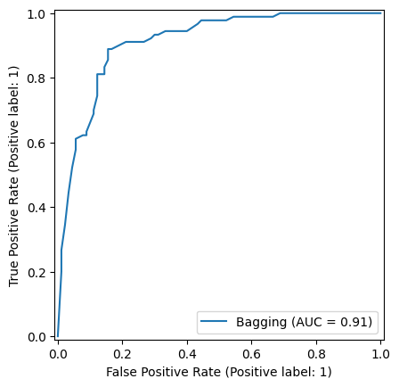

```python
evaluate_ensemble(bagging_model, X_test_original_scaled, y_test_original, model_name="Bagging")
```

**2. Boosting**

Usamos AdaBoost

```python
boosting_model = AdaBoostClassifier(
    estimator=DecisionTreeClassifier(max_depth=1, random_state=42),
    n_estimators=50,
    random_state=42
)
boosting_model.fit(X_train_original_scaled, y_train_original)

# Predicciones
y_pred_boosting = boosting_model.predict(X_test_original_scaled)
y_prob_boosting = boosting_model.predict_proba(X_test_original_scaled)[:, 1]
```

```
Evaluación del modelo: Boosting
Accuracy: 0.8111
Sensitivity (Recall para clase positiva): 0.8556
Specificity (Recall para clase negativa): 0.7667
ROC-AUC: 0.8913
Matriz de Confusión:
[[69 21]
 [13 77]]

Reporte de Clasificación:
              precision    recall  f1-score   support

         0.0       0.84      0.77      0.80        90
         1.0       0.79      0.86      0.82        90

    accuracy                           0.81       180
   macro avg       0.81      0.81      0.81       180
weighted avg       0.81      0.81      0.81       180
```

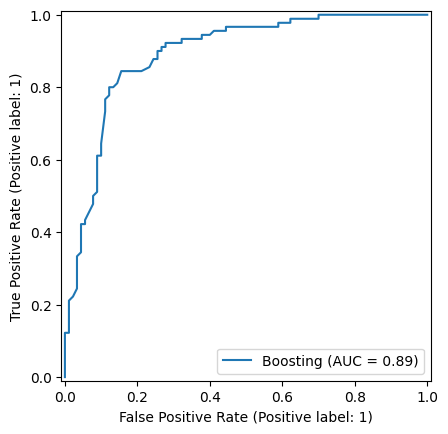

```python
evaluate_ensemble(boosting_model, X_test_original_scaled, y_test_original, model_name="Boosting")
```

**3. Stacking**

Usaremos un ensamble con múltiples modelos base.

```python
# Modelos base para stacking
estimators = [
    ('rf', RandomForestClassifier(random_state=42)),
    ('svm', SVC(probability=True, random_state=42))
]

# Stacking con Logistic Regression como meta-modelo
stacking_model = StackingClassifier(
    estimators=estimators,
    final_estimator=LogisticRegression(random_state=42)
)
stacking_model.fit(X_train_original_scaled, y_train_original)

# Predicciones
y_pred_stacking = stacking_model.predict(X_test_original_scaled)
y_prob_stacking = stacking_model.predict_proba(X_test_original_scaled)[:, 1]
```

```
Evaluación del modelo: Stacking
Accuracy: 0.8611
Sensitivity (Recall para clase positiva): 0.8556
Specificity (Recall para clase negativa): 0.8667
ROC-AUC: 0.9310
Matriz de Confusión:
[[78 12]
 [13 77]]

Reporte de Clasificación:
              precision    recall  f1-score   support

         0.0       0.86      0.87      0.86        90
         1.0       0.87      0.86      0.86        90

    accuracy                           0.86       180
   macro avg       0.86      0.86      0.86       180
weighted avg       0.86      0.86      0.86       180
```

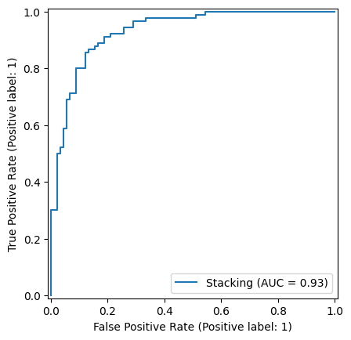

```python
evaluate_ensemble(stacking_model, X_test_original_scaled, y_test_original, model_name="Stacking")
```

**4. Cascading**

Definimos una clase personalizada para implementar el cascaded model, tal y como marca el enunciado del apartado

```python
class CascadingClassifier(BaseEstimator, ClassifierMixin):
    def __init__(self, base_model1, base_model2):
        self.base_model1 = base_model1
        self.base_model2 = base_model2

    def fit(self, X, y):
        self.base_model1.fit(X, y)
        preds = self.base_model1.predict(X).reshape(-1, 1)
        X_augmented = np.hstack((X, preds))
        self.base_model2.fit(X_augmented, y)
        return self

    def predict(self, X):
        preds = self.base_model1.predict(X).reshape(-1, 1)
        X_augmented = np.hstack((X, preds))
        return self.base_model2.predict(X_augmented)

    def predict_proba(self, X):
        preds = self.base_model1.predict(X).reshape(-1, 1)
        X_augmented = np.hstack((X, preds))
        return self.base_model2.predict_proba(X_augmented)

# Crear y entrenar el modelo cascaded
cascade_model = CascadingClassifier(
    base_model1=RandomForestClassifier(random_state=42),
    base_model2=LogisticRegression(random_state=42)
)
cascade_model.fit(X_train_original_scaled, y_train_original)

# Predicciones
y_pred_cascade = cascade_model.predict(X_test_original_scaled)
y_prob_cascade = cascade_model.predict_proba(X_test_original_scaled)[:, 1]
```

```
Evaluación del modelo: Cascading
Accuracy: 0.8500
Sensitivity (Recall para clase positiva): 0.8778
Specificity (Recall para clase negativa): 0.8222
ROC-AUC: 0.9110
Matriz de Confusión:
[[74 16]
 [11 79]]

Reporte de Clasificación:
              precision    recall  f1-score   support

         0.0       0.87      0.82      0.85        90
         1.0       0.83      0.88      0.85        90

    accuracy                           0.85       180
   macro avg       0.85      0.85      0.85       180
weighted avg       0.85      0.85      0.85       180
```

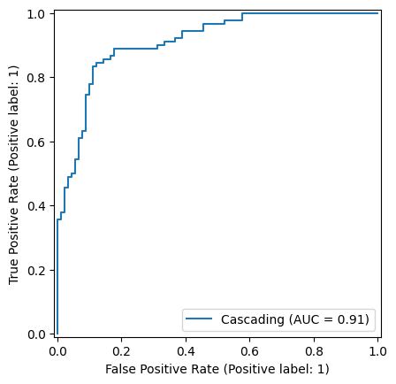

```python
evaluate_ensemble(cascade_model, X_test_original_scaled, y_test_original, model_name="Cascading")
```

**CARACTERISITCAS TRANSFORMADAS CON PCA**

**1.** **Bagging**

```python
bagging_model = BaggingClassifier(
    estimator=DecisionTreeClassifier(random_state=42),
    n_estimators=50,
    random_state=42
)
bagging_model.fit(X_train_pca, y_train_original)

# Predicciones
y_pred_bagging = bagging_model.predict(X_test_pca)
y_prob_bagging = bagging_model.predict_proba(X_test_pca)[:, 1]
```

```
Evaluación del modelo: Bagging
Accuracy: 0.8944
Sensitivity (Recall para clase positiva): 0.9444
Specificity (Recall para clase negativa): 0.8444
ROC-AUC: 0.9372
Matriz de Confusión:
[[76 14]
 [ 5 85]]

Reporte de Clasificación:
              precision    recall  f1-score   support

         0.0       0.94      0.84      0.89        90
         1.0       0.86      0.94      0.90        90

    accuracy                           0.89       180
   macro avg       0.90      0.89      0.89       180
weighted avg       0.90      0.89      0.89       180
```

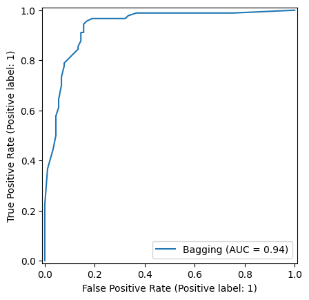

```python
evaluate_ensemble(bagging_model, X_test_pca, y_test_original, model_name="Bagging")
```

**2. Boosting**

Usamos AdaBoost

```python
boosting_model = AdaBoostClassifier(
    estimator=DecisionTreeClassifier(max_depth=1, random_state=42),
    n_estimators=50,
    random_state=42
)
boosting_model.fit(X_train_pca, y_train_original)

# Predicciones
y_pred_boosting = boosting_model.predict(X_test_pca)
y_prob_boosting = boosting_model.predict_proba(X_test_pca)[:, 1]
```

```
Evaluación del modelo: Boosting
Accuracy: 0.8056
Sensitivity (Recall para clase positiva): 0.9222
Specificity (Recall para clase negativa): 0.6889
ROC-AUC: 0.9088
Matriz de Confusión:
[[62 28]
 [ 7 83]]

Reporte de Clasificación:
              precision    recall  f1-score   support

         0.0       0.90      0.69      0.78        90
         1.0       0.75      0.92      0.83        90

    accuracy                           0.81       180
   macro avg       0.82      0.81      0.80       180
weighted avg       0.82      0.81      0.80       180
```

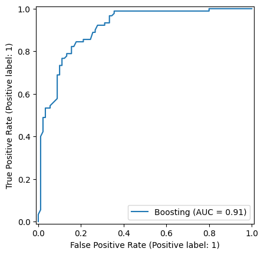

```python
evaluate_ensemble(boosting_model, X_test_pca, y_test_original, model_name="Boosting")
```

**3. Stacking**

Usaremos un ensamble con múltiples modelos base.

```python
# Modelos base para stacking
estimators = [
    ('rf', RandomForestClassifier(random_state=42)),
    ('svm', SVC(probability=True, random_state=42))
]

# Stacking con Logistic Regression como meta-modelo
stacking_model = StackingClassifier(
    estimators=estimators,
    final_estimator=LogisticRegression(random_state=42)
)
stacking_model.fit(X_train_pca, y_train_original)

# Predicciones
y_pred_stacking = stacking_model.predict(X_test_pca)
y_prob_stacking = stacking_model.predict_proba(X_test_pca)[:, 1]
```

```
Evaluación del modelo: Stacking
Accuracy: 0.8667
Sensitivity (Recall para clase positiva): 0.9222
Specificity (Recall para clase negativa): 0.8111
ROC-AUC: 0.9442
Matriz de Confusión:
[[73 17]
 [ 7 83]]

Reporte de Clasificación:
              precision    recall  f1-score   support

         0.0       0.91      0.81      0.86        90
         1.0       0.83      0.92      0.87        90

    accuracy                           0.87       180
   macro avg       0.87      0.87      0.87       180
weighted avg       0.87      0.87      0.87       180
```

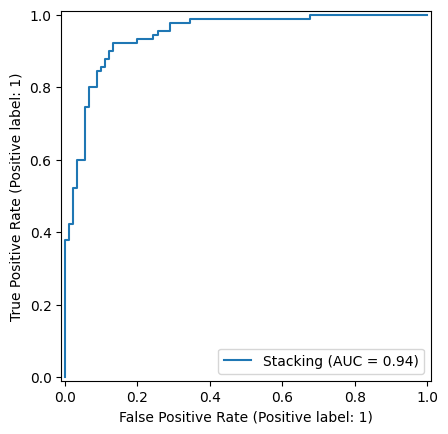

```python
evaluate_ensemble(stacking_model, X_test_pca, y_test_original, model_name="Stacking")
```

**4. Cascading**

Definimos una clase personalizada para implementar el cascaded model, tal y como marca el enunciado del apartado

```python
class CascadingClassifier(BaseEstimator, ClassifierMixin):
    def __init__(self, base_model1, base_model2):
        self.base_model1 = base_model1
        self.base_model2 = base_model2

    def fit(self, X, y):
        self.base_model1.fit(X, y)
        preds = self.base_model1.predict(X).reshape(-1, 1)
        X_augmented = np.hstack((X, preds))
        self.base_model2.fit(X_augmented, y)
        return self

    def predict(self, X):
        preds = self.base_model1.predict(X).reshape(-1, 1)
        X_augmented = np.hstack((X, preds))
        return self.base_model2.predict(X_augmented)

    def predict_proba(self, X):
        preds = self.base_model1.predict(X).reshape(-1, 1)
        X_augmented = np.hstack((X, preds))
        return self.base_model2.predict_proba(X_augmented)

# Crear y entrenar el modelo cascaded
cascade_model = CascadingClassifier(
    base_model1=RandomForestClassifier(random_state=42),
    base_model2=LogisticRegression(random_state=42)
)
cascade_model.fit(X_train_pca, y_train_original)

# Predicciones
y_pred_cascade = cascade_model.predict(X_test_pca)
y_prob_cascade = cascade_model.predict_proba(X_test_pca)[:, 1]
```

```
Evaluación del modelo: Cascading
Accuracy: 0.8833
Sensitivity (Recall para clase positiva): 0.9444
Specificity (Recall para clase negativa): 0.8222
ROC-AUC: 0.9360
Matriz de Confusión:
[[74 16]
 [ 5 85]]

Reporte de Clasificación:
              precision    recall  f1-score   support

         0.0       0.94      0.82      0.88        90
         1.0       0.84      0.94      0.89        90

    accuracy                           0.88       180
   macro avg       0.89      0.88      0.88       180
weighted avg       0.89      0.88      0.88       180
```

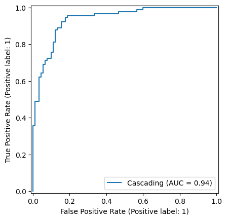

```python
evaluate_ensemble(cascade_model, X_test_pca, y_test_original, model_name="Cascading")
```

**Análisis:** Compara el rendimiento de cada método utilizando las métricas calculadas. Discute cómo se comporta cada método con las variables originales en comparación con los datos transformados por PCA. Analiza cómo el PCA afecta el rendimiento de cada método de ensemble.

**Resultados con Características Originales**

1. **Mejor Modelo:** Stacking muestra el mejor desempeño con características originales, logrando el mayor ROC-AUC (0.9310) y un balance entre sensibilidad y especificidad.
2. **Bagging y Cascading:** Ambos tienen métricas similares, destacando en sensibilidad (87.78%) y siendo efectivos en la clasificación general.
3. **Boosting:** Aunque es competitivo, tiene un desempeño ligeramente inferior en términos de especificidad, lo que indica que confunde más pacientes no diabéticos como diabéticos.

| **Modelo** | **Accuracy** | **Sensitivity** | **Specificity** | **ROC-AUC** | **Observaciones** |
| --- | --- | --- | --- | --- | --- |
| **Bagging** | 86.11% | 87.78% | 84.44% | 0.9111 | Buen balance entre sensibilidad y especificidad; desempeño consistente. |
| **Boosting** | 81.11% | 85.56% | 76.67% | 0.8913 | Mejora la sensibilidad, pero pierde algo de especificidad. |
| **Stacking** | 86.11% | 85.56% | 86.67% | **0.9310** | Mejor modelo en términos de ROC-AUC, balance entre sensibilidad y especificidad. |
| **Cascading** | 85.00% | 87.78% | 82.22% | 0.9110 | Similar a Bagging, pero con una ligera pérdida de especificidad. |

**Resultados con Componentes Principales (PCA)**

1. **Mejor Modelo (PCA):** Stacking destaca nuevamente con la mayor precisión (ROC-AUC 0.9442) y un balance sólido entre sensibilidad y especificidad.
2. **Bagging y Cascading:** Ambos modelos muestran un excelente rendimiento, especialmente en sensibilidad (94.44%), pero con una especificidad ligeramente menor.
3. **Boosting:** Aunque tiene buena sensibilidad, pierde en especificidad, indicando que clasifica más falsos positivos.

[output not shown]

**Comparativa Variables Originales vs PCA**

**1. Bagging**

Bagging con las características originales mostró un buen desempeño general, balanceando sensibilidad y especificidad. Sin embargo, presenta ciertas limitaciones en la capacidad probabilística (ROC-AUC). Sin embargo, este método con PCA mejora significativamente la sensibilidad (94.44%) y el ROC-AUC, mostrando que las componentes principales aportan información más útil y robusta para la separación entre clases.

Bagging se beneficia mucho del PCA, mejorando su capacidad de separar correctamente las clases, especialmente para los positivos (diabéticos).

**2. Boosting**

Boosting con datos originales tiene buen balance, pero tiende a tener menor especificidad (confunde más pacientes no diabéticos como diabéticos). Por otro lado, con PCA mejora la sensibilidad (92.22%) pero pierde especificidad de manera notable, aumentando los falsos positivos. Esto sugiere que Boosting es más propenso a sobreajustarse con las transformaciones de PCA.

Boosting tiene un desempeño más balanceado con las características originales. Aunque el PCA mejora el ROC-AUC, la especificidad baja drásticamente.

**3. Stacking**

Stacking es el mejor modelo con las características originales, mostrando un excelente balance entre sensibilidad y especificidad, con un alto ROC-AUC. Con PCA, Stacking mejora tanto la sensibilidad como el ROC-AUC. Aunque pierde algo de especificidad, su desempeño general sigue siendo el mejor entre los modelos.

Stacking es el modelo más robusto, con un desempeño excelente en ambas configuraciones. Con PCA, logra captar mejor las relaciones entre las clases, aumentando su sensibilidad y ROC-AUC.

**4. Cascading**

Cascading con datos originales tiene un buen balance general, destacando en sensibilidad. Por otro lado, con PCA mejora tanto la sensibilidad como el ROC-AUC, acercándose al desempeño de Bagging con PCA.

Cascading se beneficia del PCA, mejorando su capacidad para clasificar correctamente los positivos sin sacrificar demasiada especificidad.

| **Modelo** | **Accuracy (Original)** | **Accuracy (PCA)** | **ROC-AUC (Original)** | **ROC-AUC (PCA)** | **Sensibilidad (PCA - Original)** | **Especificidad (PCA - Original)** |
| --- | --- | --- | --- | --- | --- | --- |
| **Bagging** | 86.11% | 89.44% | 0.9111 | 0.9372 | +6.66% | 0.00% |
| **Boosting** | 81.11% | 80.56% | 0.8913 | 0.9088 | +6.66% | -7.78% |
| **Stacking** | 86.11% | 86.67% | 0.9310 | **0.9442** | +6.66% | -5.56% |
| **Cascading** | 85.00% | 88.33% | 0.9110 | 0.9360 | +6.66% | 0.00% |

**Stacking con PCA** es el **mejor modelo**, ya que tiene el mejor desempeño global en términos de ROC-AUC (0.9442) y un balance entre sensibilidad y especificidad.

### **5. Transfer Learning para Datos Tabulares (2 puntos)**

- 5.1. ¿Qué es el *Transfer Learning*?

El *Transfer Learning*, o aprendizaje por transferencia, es una técnica avanzada dentro del campo de la inteligencia artificial y el aprendizaje automático. La idea principal es sencilla pero muy poderosa: aprovechar el conocimiento adquirido por un modelo cuando ha sido entrenado en una tarea para aplicarlo a otra tarea diferente pero relacionada.

##### Metáfora para entenderlo

Imagina que aprendes a tocar el piano. Una vez has aprendido las bases, como leer partituras o coordinar las manos, aprender a tocar otro instrumento, como el violín, será más fácil porque muchas habilidades que has adquirido ya son aplicables. Esto es exactamente lo que hace el *Transfer Learning* en el ámbito de los modelos de aprendizaje profundo.

5.1.1. ¿Cómo funciona?

1. **Modelo preentrenado**:
   - En el *Transfer Learning*, se comienza con un modelo ya entrenado en una gran cantidad de datos generales (como imágenes de miles de categorías diferentes).
   - Este modelo ha aprendido patrones generales (por ejemplo, identificar líneas, formas y texturas en imágenes).
2. **Transferencia de conocimiento**:
   - Se reutilizan las primeras capas del modelo preentrenado, que contienen este conocimiento general.
   - Solo es necesario ajustar (o añadir) las capas finales para que el modelo pueda especializarse en la nueva tarea específica.
3. **Entrenamiento con datos específicos**:
   - Con un conjunto más pequeño de datos específicos de la tarea (como imágenes de pacientes con o sin diabetes), el modelo se entrena para refinar el conocimiento y adaptarse.

5.1.2. ¿Por qué utilizar el *Transfer Learning*?

1. **Ahorro de tiempo y recursos**:
   - No es necesario entrenar un modelo desde cero, ya que el modelo preentrenado ya ha realizado gran parte del trabajo de aprendizaje.
   - Esto reduce significativamente el tiempo y los costos computacionales.
2. **Mayor rendimiento con datos limitados**:
   - Si solo disponemos de un conjunto pequeño de datos específicos, el *Transfer Learning* ayuda a evitar problemas como el sobreajuste (*overfitting*), aprovechando el conocimiento previo.
3. **Resultados robustos**:
   - Los modelos preentrenados ya han sido probados con grandes conjuntos de datos, lo que garantiza una base sólida y generalizable para trabajar.

##### Ejemplo práctico

Supongamos que queremos clasificar si una imagen muestra a un paciente con diabetes o no. Podemos utilizar un modelo preentrenado como ResNet50 (que ha aprendido a reconocer patrones generales de imágenes) y adaptarlo a nuestra tarea, sin necesidad de entrenarlo desde cero.

El *Transfer Learning* permite enfocarnos en nuestra tarea específica sin perder tiempo construyendo y entrenando un modelo completamente nuevo. Es como subirse a los hombros de un gigante para llegar más lejos.

Con este conocimiento básico, ya podemos entrar en detalle sobre cómo implementar el *Transfer Learning* y aprovecharlo para mejorar nuestros resultados. Los pasos serán los siguientes:

- Adaptar un modelo de red neuronal preentrenado (ResNet50) para datos tabulares.
- Entrenar el modelo utilizando los datos preprocesados y comparar el rendimiento con los métodos de ensemble.
- Evaluar el modelo utilizando exactitud, sensibilidad, especificidad, ROC-AUC y matriz de confusión.
- 5.2. Adaptación del modelo ResNet50**

En este apartado, transformaremos los datos tabulares en una forma que pueda ser procesada por un modelo personalizado, como un **Custom CNN**, o adaptada para una arquitectura como **ResNet50**. Esto implica representar los datos tabulares como "imágenes" (matrices en 2D o 3D) para cumplir con los requisitos de entrada del modelo.

5.2.1. ¿Por qué es necesario transformar los datos tabulares? Los modelos convolucionales, como ResNet50, están diseñados para trabajar con datos en forma de matrices (altura, anchura, canales), habitualmente para procesar imágenes. En el caso de nuestros datos:

- Los datos originales tienen **8 características** (por ejemplo, `Glucose`, `BMI`, etc.).
- Los datos PCA tienen **7 componentes principales**, que son combinaciones lineales de las características originales.

Como estas características son unidimensionales, es necesario transformarlas para que el modelo pueda procesarlas como "imágenes artificiales".

5.2.2. ¿Cómo se transforma una matriz unidimensional en una "imagen"?

Para convertir los datos tabulares en "imágenes", debemos:

1. **Decidir la forma de entrada (`input_shape`):**
   - Los datos originales con **8 características** se pueden reorganizar en una matriz de **(2 x 4 x 1)** (2 filas, 4 columnas y 1 canal).
   - Los datos PCA con **7 componentes principales** se pueden reorganizar en una matriz de **(7 x 1 x 1)**.
2. **Validar la forma de los datos:**
   - El número total de características debe coincidir con el producto ( altura x anchura x canales ).
   - Por ejemplo, para los datos originales, ( 2 x 4 x 1 = 8 ), que corresponde al número de características.
3. **Aplicar la transformación:**
   - Reorganizamos cada muestra para que tenga la forma adecuada mediante un código personalizado.

**Implementación:** Aplica los pasos descritos anteriormente para transformar los datos tabulares en imágenes:

```python
def transform_to_images(data, input_shape):
    """
    Transforma datos tabulares en un formato adecuado para modelos convolucionales.

    :param data: DataFrame o matriz de entrada con datos tabulares
    :param input_shape: Tuple con la forma deseada (altura, ancho, canales)
    :return: Matriz transformada en forma de "imágenes"
    """
    # Validar que las dimensiones coincidan
    assert np.prod(input_shape) == data.shape[1], \
        f"El producto de las dimensiones {input_shape} no coincide con el número de características {data.shape[1]}"

    # Transformar cada muestra
    data_reshaped = data.values.reshape(data.shape[0], *input_shape)
    return data_reshaped
```

- 5.3 Transformación de los datos
1. **Datos originales (8 características):** Los datos originales con 8 características se pueden reorganizar en una matriz de (2 x 4 x 1) (2 filas, 4 columnas y 1 canal).

**Implementación:** Reorganiza los datos en una matriz de (2x4x1):

```python
input_shape_original = (2, 4, 1)
X_train_images_original = transform_to_images(X_train_original_scaled, input_shape_original)
X_test_images_original = transform_to_images(X_test_original_scaled, input_shape_original)
```

2. **Datos PCA (7 componentes principales):**  
   Los datos PCA con 7 componentes principales se pueden reorganizar en una matriz de (7 x 1 x 1).

**Implementación:** Reorganiza los datos en una matriz de (7x1x1):

```python
input_shape_pca = (7, 1, 1)
X_train_images_pca = transform_to_images(X_train_pca, input_shape_pca)
X_test_images_pca = transform_to_images(X_test_pca, input_shape_pca)
```

- **5.4. Conversión de datos a float32**

**¿Por qué es necesario convertir los datos a `float32`?**

En el ámbito del aprendizaje automático y el procesamiento de datos, es habitual que sea necesario convertir los datos al formato `float32`. Pros:

**Eficiencia de memoria**

- **Reducción del uso de memoria**: El formato `float32` utiliza 4 bytes de memoria, mientras que `float64` (el formato predeterminado en muchas librerías como NumPy o Pandas) utiliza 8 bytes. En conjuntos de datos grandes, esta diferencia puede reducir significativamente el consumo de memoria.
- **Adaptabilidad para GPUs**: Las GPUs suelen trabajar con `float32` de manera nativa. Utilizar este formato evita un uso innecesario de memoria y mejora la eficiencia computacional.

**Optimización del rendimiento**

- **Cálculos más rápidos**: Los cálculos con `float32` son más rápidos que con `float64`, especialmente en GPUs, ya que muchas herramientas de aprendizaje profundo (como TensorFlow o PyTorch) están optimizadas para `float32`.
- **Tiempo de transferencia reducido**: Transferir datos entre CPU y GPU es más rápido cuando los datos están en formato `float32`, gracias al menor volumen de datos.

**Evitar problemas de compatibilidad**

- **Requisitos de las herramientas**: Muchas herramientas de aprendizaje automático, como TensorFlow o Keras, esperan que los datos de entrada estén en formato `float32`. Si se utiliza `float64`, se pueden generar advertencias o errores que obligarán a hacer la conversión posteriormente.
- **Modelos preentrenados**: La mayoría de los modelos preentrenados y operaciones en aprendizaje profundo están diseñados para trabajar con `float32`. Esto asegura la compatibilidad y evita desajustes entre tipos de datos.

**Impacto mínimo en la precisión**

- **Precisión suficiente**: Para la mayoría de tareas de aprendizaje automático, la precisión que ofrece `float32` es más que suficiente. Aunque `float64` proporciona una precisión más alta, esta normalmente no es necesaria en aplicaciones prácticas.
- **Control de errores**: El formato `float32` ayuda a mitigar problemas como desbordamientos o subdesbordamientos de valores, que pueden ser más probables con `float64`.

**Buenas prácticas en la industria**

- **Consistencia**: Mantener el mismo tipo de datos en toda la pipeline (entrada, pesos del modelo, salidas) evita comportamientos inesperados o incompatibilidades durante los cálculos.
- **Estándar**: La mayoría de librerías y herramientas de aprendizaje automático utilizan `float32` como formato predeterminado. Esto hace que este formato sea un estándar para garantizar la compatibilidad.

**¿Cuándo no es necesario convertir a `float32`?**

- **Requisitos de alta precisión**: Si la aplicación requiere cálculos muy precisos (por ejemplo, simulaciones científicas), podría ser más adecuado utilizar `float64`.
- **Conjuntos de datos pequeños**: Si el conjunto de datos es pequeño y el consumo de memoria no es un problema, la conversión puede no ser imprescindible.

Por tanto, a la hora de preparar los datos para una pipeline de aprendizaje automático, **debes convertirlos a `float32` para mejorar el rendimiento, reducir el consumo de memoria y garantizar la compatibilidad con las herramientas modernas.** Esto es especialmente importante si estás trabajando con conjuntos de datos grandes o entrenando modelos en GPUs.

**Implementación:** Convierte los datos originales y los componentes principales (PCs) a `float32`.

```python
# Conversión de los datos originales a float32
X_train_images_original = X_train_images_original.astype('float32')
X_test_images_original = X_test_images_original.astype('float32')

# Conversión de los datos PCA a float32
X_train_images_pca = X_train_images_pca.astype('float32')
X_test_images_pca = X_test_images_pca.astype('float32')
```

- Errores comunes y cómo evitarlos
1. **Forma de entrada incorrecta:**
   - Si el número de características no coincide con el producto de la forma de entrada especificada, aparecerá un error.
   - **Solución:** Comprueba que el número de características (n) = (altura x anchura x canales).
2. **Transformación repetida:**
   - Transformar los datos repetidamente puede generar errores.
   - **Solución:** Utiliza solo los datos transformados (por ejemplo, `X_train_original_reshaped`) en entrenamientos posteriores.
3. **Diferencias en las dimensiones entre datos de entrenamiento y test:**
   - Si los datos de entrenamiento y test tienen dimensiones diferentes, ResNet50 no podrá procesarlos.
   - **Solución:** Asegúrate de que la transformación se aplica de manera consistente a todos los datos.

**Implementación:** Antes de entrenar el modelo, asegúrate de que los datos tienen la forma correcta:

```python
# Forma de entrada

# Originales
assert X_train_images_original.shape[1:] == (2, 4, 1), \
    f"Forma incorrecta para los datos originales transformados: {X_train_images_original.shape[1:]}"
assert X_test_images_original.shape[1:] == (2, 4, 1), \
    f"Forma incorrecta para los datos originales de test: {X_test_images_original.shape[1:]}"

# PCA
assert X_train_images_pca.shape[1:] == (7, 1, 1), \
    f"Forma incorrecta para los datos PCA transformados: {X_train_images_pca.shape[1:]}"
assert X_test_images_pca.shape[1:] == (7, 1, 1), \
    f"Forma incorrecta para los datos PCA de test: {X_test_images_pca.shape[1:]}"
```

```python
# Consistencia entre Entrenamiento y Test

# Originales
assert X_train_images_original.shape[1:] == X_test_images_original.shape[1:], \
    "Las dimensiones de los datos originales no son consistentes entre entrenamiento y test."

# PCA
assert X_train_images_pca.shape[1:] == X_test_images_pca.shape[1:], \
    "Las dimensiones de los datos PCA no son consistentes entre entrenamiento y test."
```

```python
# tipos de datos
print("Datos Originales (entrenamiento):", X_train_images_original.shape, X_train_images_original.dtype)
print("Datos Originales (test):", X_test_images_original.shape, X_test_images_original.dtype)
print("Datos PCA (entrenamiento):", X_train_images_pca.shape, X_train_images_pca.dtype)
print("Datos PCA (test):", X_test_images_pca.shape, X_test_images_pca.dtype)
```

```
Datos Originales (entrenamiento): (716, 2, 4, 1) float32
Datos Originales (test): (180, 2, 4, 1) float32
Datos PCA (entrenamiento): (716, 7, 1, 1) float32
Datos PCA (test): (180, 7, 1, 1) float32
```

- 5.5. Entrena el modelo utilizando los datos preprocesados y compara el rendimiento con los métodos de ensemble.

Args:

- X_train: Datos de entrenamiento (ya transformados).
- X_test: Datos de prueba (ya transformados).
- y_train: Etiquetas de entrenamiento.
- y_test: Etiquetas de prueba.
- input_shape: Forma de los datos de entrada.
- dataset_type: Cadena que indica si el conjunto de datos es "original" o "pca".
- Imprime: métricas de evaluación y dibuja la curva ROC.

**Implementación:** Crea la función para una CNN personalizada para los datos tabulares remodelados en pequeñas estructuras similares a imágenes en 2D.

```python
def create_custom_cnn(input_shape):
    """
    Crea un modelo CNN personalizado para datos tabulares remodelados.

    Args:
        input_shape (tuple): Forma de entrada de los datos (altura, anchura, canales).

    Returns:
        model: Modelo CNN compilado.
    """
    model = Sequential()
    model.add(Input(shape=input_shape))

    # Primera capa convolucional
    model.add(Conv2D(32, kernel_size=(3, 3), activation='relu', input_shape=input_shape, padding='same'))
    model.add(BatchNormalization())

    # Segunda capa convolucional
    model.add(Conv2D(64, kernel_size=(3, 3), activation='relu', padding='same'))
    model.add(BatchNormalization())

    # Aplanamiento
    model.add(Flatten())

    # Capas densas completamente conectadas
    model.add(Dense(128, activation='relu'))
    model.add(Dropout(0.5))
    model.add(Dense(64, activation='relu'))
    model.add(Dropout(0.5))

    # Capa de salida
    model.add(Dense(1, activation='sigmoid'))

    # Compilación
    model.compile(optimizer=Adam(learning_rate=0.001),
                  loss='binary_crossentropy',
                  metrics=['accuracy'])

    return model
```

**Implementación:** Crea la función para entrenar y evaluar un modelo CNN personalizado para datos tabulares remodelados como imágenes.

```python
def train_and_evaluate_custom_cnn(X_train, X_test, y_train, y_test, input_shape, dataset_type):
    """
    Entrena y evalúa una CNN personalizada para datos tabulares remodelados como imágenes.

    Args:
        X_train (np.array): Datos de entrenamiento remodelados.
        X_test (np.array): Datos de prueba remodelados.
        y_train (np.array): Etiquetas de entrenamiento.
        y_test (np.array): Etiquetas de prueba.
        input_shape (tuple): Forma de los datos de entrada (altura, anchura, canales).
        dataset_type (str): Cadena que indica si los datos son "original" o "pca".

    Returns:
        model: Modelo entrenado.
        history: Historial del entrenamiento.
    """
    # Crear el modelo CNN personalizado
    model = create_custom_cnn(input_shape)

    # Entrenar el modelo
    history = model.fit(
        X_train, y_train,
        validation_data=(X_test, y_test),
        epochs=30,
        batch_size=32,
        verbose=1
    )

    # Evaluación del modelo
    y_pred = model.predict(X_test).ravel()
    y_pred_class = (y_pred > 0.5).astype(int)

    # Calcular métricas
    accuracy = accuracy_score(y_test, y_pred_class)
    sensitivity = recall_score(y_test, y_pred_class)
    specificity = recall_score(y_test, y_pred_class, pos_label=0)
    roc_auc = roc_auc_score(y_test, y_pred)
    conf_matrix = confusion_matrix(y_test, y_pred_class)
    classification_rep = classification_report(y_test, y_pred_class)

    # Mostrar resultados
    print(f"\nResultados del Modelo CNN ({dataset_type}):")
    print(f"Exactitud: {accuracy:.4f}")
    print(f"Sensibilidad: {sensitivity:.4f}")
    print(f"Especificidad: {specificity:.4f}")
    print(f"ROC-AUC: {roc_auc:.4f}")
    print(f"Matriz de Confusión:\n{conf_matrix}")
    print("\nReporte de Clasificación:")
    print(classification_rep)

    # Curva ROC
    fpr, tpr, _ = roc_curve(y_test, y_pred)
    plt.figure(figsize=(6, 6))
    plt.plot(fpr, tpr, label=f"CNN ({dataset_type}) - AUC: {roc_auc:.4f}")
    plt.plot([0, 1], [0, 1], linestyle='--', color='gray')
    plt.xlabel("Tasa de Falsos Positivos (FPR)")
    plt.ylabel("Tasa de Verdaderos Positivos (TPR)")
    plt.title(f"Curva ROC - CNN ({dataset_type})")
    plt.legend()
    plt.show()

    return model, history
```

- 5.6. Evaluación de los modelos

**Implementación:** Evalúe el modelo con los datos originales utilizando exactitud, sensibilidad, especificidad, ROC-AUC y matriz de confusión.

```
23/23 ━━━━━━━━━━━━━━━━━━━━ 4s 26ms/step - accuracy: 0.6131 - loss: 0.8415 - val_accuracy: 0.7889 - val_loss: 0.6426
23/23 ━━━━━━━━━━━━━━━━━━━━ 1s 7ms/step - accuracy: 0.8017 - loss: 0.4240 - val_accuracy: 0.7611 - val_loss: 0.6296
23/23 ━━━━━━━━━━━━━━━━━━━━ 0s 7ms/step - accuracy: 0.8000 - loss: 0.4817 - val_accuracy: 0.7167 - val_loss: 0.6338
23/23 ━━━━━━━━━━━━━━━━━━━━ 0s 6ms/step - accuracy: 0.8074 - loss: 0.4042 - val_accuracy: 0.6222 - val_loss: 0.6332
23/23 ━━━━━━━━━━━━━━━━━━━━ 0s 7ms/step - accuracy: 0.8612 - loss: 0.3766 - val_accuracy: 0.6222 - val_loss: 0.6258
23/23 ━━━━━━━━━━━━━━━━━━━━ 0s 7ms/step - accuracy: 0.8253 - loss: 0.3801 - val_accuracy: 0.6556 - val_loss: 0.6064
23/23 ━━━━━━━━━━━━━━━━━━━━ 0s 7ms/step - accuracy: 0.8682 - loss: 0.3640 - val_accuracy: 0.6111 - val_loss: 0.6051
23/23 ━━━━━━━━━━━━━━━━━━━━ 0s 8ms/step - accuracy: 0.8482 - loss: 0.3614 - val_accuracy: 0.6000 - val_loss: 0.6020
23/23 ━━━━━━━━━━━━━━━━━━━━ 0s 7ms/step - accuracy: 0.8442 - loss: 0.4189 - val_accuracy: 0.6722 - val_loss: 0.5536
23/23 ━━━━━━━━━━━━━━━━━━━━ 0s 7ms/step - accuracy: 0.8787 - loss: 0.3089 - val_accuracy: 0.6944 - val_loss: 0.5473
23/23 ━━━━━━━━━━━━━━━━━━━━ 0s 7ms/step - accuracy: 0.8668 - loss: 0.3100 - val_accuracy: 0.7000 - val_loss: 0.5272
23/23 ━━━━━━━━━━━━━━━━━━━━ 0s 7ms/step - accuracy: 0.8814 - loss: 0.2820 - val_accuracy: 0.7667 - val_loss: 0.4812
23/23 ━━━━━━━━━━━━━━━━━━━━ 0s 7ms/step - accuracy: 0.8954 - loss: 0.2721 - val_accuracy: 0.8000 - val_loss: 0.4671
23/23 ━━━━━━━━━━━━━━━━━━━━ 0s 7ms/step - accuracy: 0.8660 - loss: 0.2964 - val_accuracy: 0.7944 - val_loss: 0.4480
23/23 ━━━━━━━━━━━━━━━━━━━━ 0s 7ms/step - accuracy: 0.8847 - loss: 0.2752 - val_accuracy: 0.8000 - val_loss: 0.4280
23/23 ━━━━━━━━━━━━━━━━━━━━ 0s 7ms/step - accuracy: 0.9165 - loss: 0.2310 - val_accuracy: 0.8222 - val_loss: 0.4136
23/23 ━━━━━━━━━━━━━━━━━━━━ 0s 7ms/step - accuracy: 0.9124 - loss: 0.2113 - val_accuracy: 0.8111 - val_loss: 0.4117
23/23 ━━━━━━━━━━━━━━━━━━━━ 0s 8ms/step - accuracy: 0.8907 - loss: 0.2421 - val_accuracy: 0.8333 - val_loss: 0.4050
23/23 ━━━━━━━━━━━━━━━━━━━━ 0s 7ms/step - accuracy: 0.9339 - loss: 0.1834 - val_accuracy: 0.8333 - val_loss: 0.3722
23/23 ━━━━━━━━━━━━━━━━━━━━ 0s 7ms/step - accuracy: 0.9098 - loss: 0.2059 - val_accuracy: 0.8333 - val_loss: 0.4004
23/23 ━━━━━━━━━━━━━━━━━━━━ 0s 7ms/step - accuracy: 0.9130 - loss: 0.2050 - val_accuracy: 0.8167 - val_loss: 0.4049
23/23 ━━━━━━━━━━━━━━━━━━━━ 0s 7ms/step - accuracy: 0.9176 - loss: 0.1986 - val_accuracy: 0.8222 - val_loss: 0.4169
23/23 ━━━━━━━━━━━━━━━━━━━━ 0s 7ms/step - accuracy: 0.9175 - loss: 0.1810 - val_accuracy: 0.8333 - val_loss: 0.4402
23/23 ━━━━━━━━━━━━━━━━━━━━ 0s 7ms/step - accuracy: 0.9414 - loss: 0.1422 - val_accuracy: 0.8500 - val_loss: 0.4102
23/23 ━━━━━━━━━━━━━━━━━━━━ 0s 7ms/step - accuracy: 0.9389 - loss: 0.1564 - val_accuracy: 0.8000 - val_loss: 0.5180
23/23 ━━━━━━━━━━━━━━━━━━━━ 0s 7ms/step - accuracy: 0.9333 - loss: 0.1715 - val_accuracy: 0.8611 - val_loss: 0.4010
23/23 ━━━━━━━━━━━━━━━━━━━━ 0s 7ms/step - accuracy: 0.9390 - loss: 0.1348 - val_accuracy: 0.8500 - val_loss: 0.4281
23/23 ━━━━━━━━━━━━━━━━━━━━ 0s 8ms/step - accuracy: 0.9310 - loss: 0.1552 - val_accuracy: 0.8444 - val_loss: 0.4433
23/23 ━━━━━━━━━━━━━━━━━━━━ 0s 7ms/step - accuracy: 0.9269 - loss: 0.1537 - val_accuracy: 0.8556 - val_loss: 0.5132
23/23 ━━━━━━━━━━━━━━━━━━━━ 0s 8ms/step - accuracy: 0.9388 - loss: 0.1325 - val_accuracy: 0.8611 - val_loss: 0.4180
6/6 ━━━━━━━━━━━━━━━━━━━━ 0s 19ms/step

Resultados del Modelo CNN (original):
Exactitud: 0.8611
Sensibilidad: 0.8889
Especificidad: 0.8333
ROC-AUC: 0.9312
Matriz de Confusión:
[[75 15]
 [10 80]]

Reporte de Clasificación:
              precision    recall  f1-score   support

         0.0       0.88      0.83      0.86        90
         1.0       0.84      0.89      0.86        90

    accuracy                           0.86       180
   macro avg       0.86      0.86      0.86       180
weighted avg       0.86      0.86      0.86       180
```

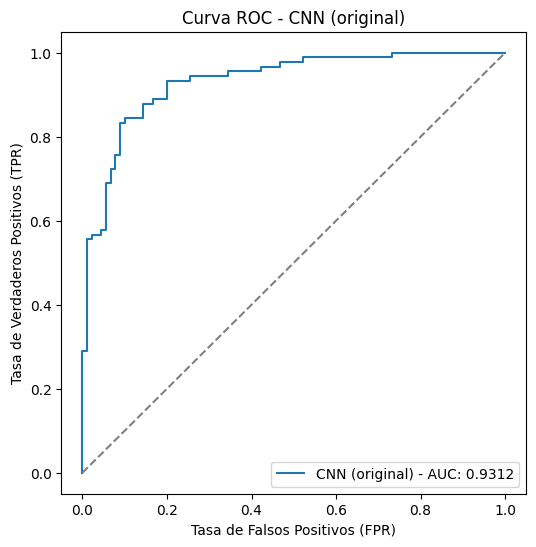

```python
model_original, history_original = train_and_evaluate_custom_cnn(
    X_train_images_original,
    X_test_images_original,
    y_train_original,
    y_test_original,
    input_shape=(2, 4, 1),
    dataset_type="original"
)
```

**Implementación:** Evalúe el modelo con los datos con PCA utilizando exactitud, sensibilidad, especificidad, ROC-AUC y matriz de confusión.

```
23/23 ━━━━━━━━━━━━━━━━━━━━ 4s 26ms/step - accuracy: 0.6736 - loss: 0.7263 - val_accuracy: 0.7944 - val_loss: 0.6658
23/23 ━━━━━━━━━━━━━━━━━━━━ 0s 12ms/step - accuracy: 0.7672 - loss: 0.5305 - val_accuracy: 0.6056 - val_loss: 0.6725
23/23 ━━━━━━━━━━━━━━━━━━━━ 0s 11ms/step - accuracy: 0.7633 - loss: 0.4927 - val_accuracy: 0.5111 - val_loss: 0.6746
23/23 ━━━━━━━━━━━━━━━━━━━━ 0s 12ms/step - accuracy: 0.7876 - loss: 0.4715 - val_accuracy: 0.5222 - val_loss: 0.6707
23/23 ━━━━━━━━━━━━━━━━━━━━ 1s 12ms/step - accuracy: 0.8187 - loss: 0.3905 - val_accuracy: 0.5000 - val_loss: 0.6640
23/23 ━━━━━━━━━━━━━━━━━━━━ 1s 7ms/step - accuracy: 0.8190 - loss: 0.4109 - val_accuracy: 0.5056 - val_loss: 0.6586
23/23 ━━━━━━━━━━━━━━━━━━━━ 0s 6ms/step - accuracy: 0.7990 - loss: 0.4291 - val_accuracy: 0.5222 - val_loss: 0.6576
23/23 ━━━━━━━━━━━━━━━━━━━━ 0s 7ms/step - accuracy: 0.8267 - loss: 0.4117 - val_accuracy: 0.5278 - val_loss: 0.6470
23/23 ━━━━━━━━━━━━━━━━━━━━ 0s 6ms/step - accuracy: 0.7940 - loss: 0.4069 - val_accuracy: 0.5833 - val_loss: 0.6381
23/23 ━━━━━━━━━━━━━━━━━━━━ 0s 7ms/step - accuracy: 0.8144 - loss: 0.3907 - val_accuracy: 0.6056 - val_loss: 0.6231
23/23 ━━━━━━━━━━━━━━━━━━━━ 0s 6ms/step - accuracy: 0.8269 - loss: 0.4172 - val_accuracy: 0.5944 - val_loss: 0.6112
23/23 ━━━━━━━━━━━━━━━━━━━━ 0s 7ms/step - accuracy: 0.8523 - loss: 0.3621 - val_accuracy: 0.6389 - val_loss: 0.5997
23/23 ━━━━━━━━━━━━━━━━━━━━ 0s 6ms/step - accuracy: 0.8603 - loss: 0.3310 - val_accuracy: 0.6556 - val_loss: 0.5848
23/23 ━━━━━━━━━━━━━━━━━━━━ 0s 8ms/step - accuracy: 0.8367 - loss: 0.3522 - val_accuracy: 0.6556 - val_loss: 0.5577
23/23 ━━━━━━━━━━━━━━━━━━━━ 0s 6ms/step - accuracy: 0.8540 - loss: 0.3232 - val_accuracy: 0.6944 - val_loss: 0.5315
23/23 ━━━━━━━━━━━━━━━━━━━━ 0s 7ms/step - accuracy: 0.8464 - loss: 0.3612 - val_accuracy: 0.6944 - val_loss: 0.5316
23/23 ━━━━━━━━━━━━━━━━━━━━ 0s 7ms/step - accuracy: 0.8720 - loss: 0.2805 - val_accuracy: 0.7333 - val_loss: 0.4707
23/23 ━━━━━━━━━━━━━━━━━━━━ 0s 7ms/step - accuracy: 0.8648 - loss: 0.3111 - val_accuracy: 0.7722 - val_loss: 0.4466
23/23 ━━━━━━━━━━━━━━━━━━━━ 0s 7ms/step - accuracy: 0.8669 - loss: 0.3170 - val_accuracy: 0.7944 - val_loss: 0.4121
23/23 ━━━━━━━━━━━━━━━━━━━━ 0s 7ms/step - accuracy: 0.8737 - loss: 0.3121 - val_accuracy: 0.8000 - val_loss: 0.4073
23/23 ━━━━━━━━━━━━━━━━━━━━ 0s 7ms/step - accuracy: 0.8617 - loss: 0.3168 - val_accuracy: 0.8278 - val_loss: 0.3665
23/23 ━━━━━━━━━━━━━━━━━━━━ 0s 6ms/step - accuracy: 0.8943 - loss: 0.2710 - val_accuracy: 0.8611 - val_loss: 0.3666
23/23 ━━━━━━━━━━━━━━━━━━━━ 0s 7ms/step - accuracy: 0.9037 - loss: 0.2306 - val_accuracy: 0.8333 - val_loss: 0.3664
23/23 ━━━━━━━━━━━━━━━━━━━━ 0s 7ms/step - accuracy: 0.8920 - loss: 0.2412 - val_accuracy: 0.8778 - val_loss: 0.3504
23/23 ━━━━━━━━━━━━━━━━━━━━ 0s 8ms/step - accuracy: 0.8944 - loss: 0.2443 - val_accuracy: 0.8778 - val_loss: 0.3499
23/23 ━━━━━━━━━━━━━━━━━━━━ 0s 7ms/step - accuracy: 0.8820 - loss: 0.2521 - val_accuracy: 0.8167 - val_loss: 0.3938
23/23 ━━━━━━━━━━━━━━━━━━━━ 0s 7ms/step - accuracy: 0.8951 - loss: 0.2693 - val_accuracy: 0.8722 - val_loss: 0.3173
23/23 ━━━━━━━━━━━━━━━━━━━━ 0s 6ms/step - accuracy: 0.9253 - loss: 0.2243 - val_accuracy: 0.8722 - val_loss: 0.3280
23/23 ━━━━━━━━━━━━━━━━━━━━ 0s 8ms/step - accuracy: 0.9213 - loss: 0.2134 - val_accuracy: 0.8667 - val_loss: 0.3395
23/23 ━━━━━━━━━━━━━━━━━━━━ 0s 6ms/step - accuracy: 0.9267 - loss: 0.2204 - val_accuracy: 0.8611 - val_loss: 0.3559
6/6 ━━━━━━━━━━━━━━━━━━━━ 0s 20ms/step

Resultados del Modelo CNN (pca):
Exactitud: 0.8611
Sensibilidad: 0.9333
Especificidad: 0.7889
ROC-AUC: 0.9389
Matriz de Confusión:
[[71 19]
 [ 6 84]]

Reporte de Clasificación:
              precision    recall  f1-score   support

         0.0       0.92      0.79      0.85        90
         1.0       0.82      0.93      0.87        90

    accuracy                           0.86       180
   macro avg       0.87      0.86      0.86       180
weighted avg       0.87      0.86      0.86       180
```

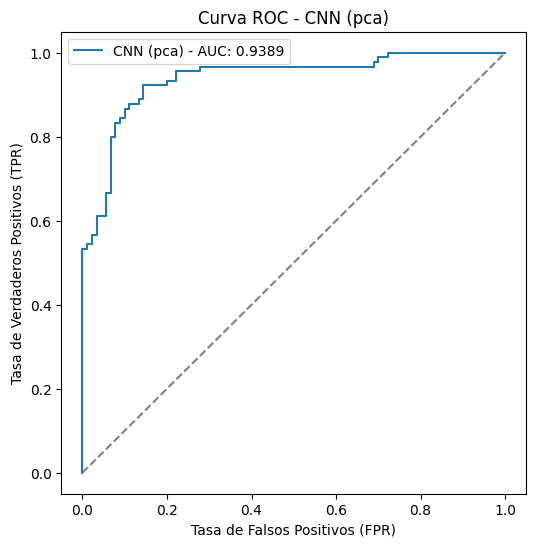

```python
model_pca, history_pca = train_and_evaluate_custom_cnn(
    X_train_images_pca,
    X_test_images_pca,
    y_train_pca,
    y_test_pca,
    input_shape=(7, 1, 1),
    dataset_type="pca"
)
```

- 5.7. Análisis

**Análisis:** Analiza los resultados de las dos implementaciones del modelo CNN personalizado, una con datos originales y otra con datos transformados con PCA.

**Comparativa entre los modelos con datos originales y PCA transformados**

| Métrica | CNN (original) | CNN (PCA) |
| --- | --- | --- |
| Exactitud | 0.8611 | **0.8611** |
| Sensibilidad | 0.8889 | **0.9333** |
| Especificidad | **0.8333** | 0.7889 |
| ROC-AUC | 0.9312 | **0.9389** |

El **modelo PCA** se desempeña mejor en términos de sensibilidad y ROC-AUC, lo que lo hace más adecuado para identificar correctamente a los pacientes diabéticos. Por otro lado, el **modelo original** tiene una ligera ventaja en especificidad, lo que podría ser relevante si el objetivo es minimizar los falsos positivos.

- 5.8. **Comparativa entre CNN personalizada y métodos de ensemble**

**Análisis:** Compara los resultados obtenidos con la CNN personalizada y los métodos de ensemble (Bagging, Boosting, Stacking y Cascading), tanto con los datos originales como con los datos transformados mediante PCA. Identifica qué métodos son más efectivos en función de las métricas clave: Accuracy, Sensitivity, Specificity y ROC-AUC.

A continuación se comparan los resultados de la **CNN personalizada** y los **métodos de ensemble (Bagging, Boosting, Stacking, Cascading)** para las métricas clave.

| Modelo | Datos | Accuracy | Sensitivity | Specificity | ROC-AUC |
| --- | --- | --- | --- | --- | --- |
| **Bagging** | Original | 0.8611 | 0.8778 | **0.8444** | 0.9111 |
| **Boosting** | Original | 0.8111 | 0.8556 | 0.7667 | 0.8913 |
| **Stacking** | Original | 0.8611 | 0.8556 | 0.8667 | 0.9310 |
| **Cascading** | Original | 0.8500 | 0.8778 | 0.8222 | 0.9110 |
| **CNN Personalizada** | Original | 0.8611 | 0.8889 | 0.8333 | 0.9312 |
| **Bagging** | PCA | **0.8944** | **0.9444** | **0.8444** | 0.9372 |
| **Boosting** | PCA | 0.8056 | 0.9222 | 0.6889 | 0.9088 |
| **Stacking** | PCA | 0.8667 | 0.9222 | 0.8111 | **0.9442** |
| **Cascading** | PCA | 0.8833 | **0.9444** | 0.8222 | 0.9360 |
| **CNN Personalizada** | PCA | 0.8611 | 0.9333 | 0.7889 | 0.9389 |

**Resultados**

**Análisis Comparativo**

1. **Ventajas de los Métodos de Ensemble:** Los métodos de ensemble tienden a ser más robustos y logran un mejor rendimiento en métricas globales como accuracy y ROC-AUC. Bagging, en particular, ofrece un excelente equilibrio entre sensibilidad y especificidad, tanto con los datos originales como con los PCA.
2. **Ventajas de la CNN Personalizada:** Con los datos originales, la CNN muestra una alta sensibilidad, lo cual es valioso en aplicaciones donde la detección de casos positivos es prioritaria.Con los PCA, la CNN se mantiene competitiva, con un rendimiento general comparable a los métodos de ensemble.
3. **Impacto del PCA:** La transformación mediante PCA mejora notablemente el rendimiento en casi todos los métodos, especialmente en accuracy y ROC-AUC. Esto sugiere que la reducción de dimensionalidad facilita que los modelos encuentren patrones más claros en los datos.
4. **Mejor Modelo Global:** **Stacking con PCA** ofrece el mejor equilibrio entre todas las métricas, con un ROC-AUC de 94.4% y una accuracy de 86.7%. Sin embargo, **Bagging con PCA** se destaca por tener la mejor accuracy (89.4%) y una sensibilidad sobresaliente (94.4%).

**Conclusiones**

## **6. Optimización del Modelo y Ajuste de Hiperparámetros (2 puntos)**

- 6.1. Ajuste de hiperparámetros con GridSearchCV para el mejor modelo de ensemble

**Implementación:** Seleccione el modelo de ensemble con mejor rendimiento (por ejemplo, Stacking o Bagging). Defina una cuadrícula de hiperparámetros relevantes. Por ejemplo: Para Bagging: Número de estimadores (n_estimators), tamaño máximo de muestras (max_samples); Para Stacking: Modelos base y parámetros asociados a los clasificadores meta. Utilice GridSearchCV para explorar las combinaciones posibles de los hiperparámetros y seleccionar la mejor configuración.

Para el ajuste de los hiperparámetros se ha elegido utilizar el modelo **bagging**.

Bagging se destaca en los resultados por su combinación equilibrada de alta exactitud (Accuracy), alta sensibilidad (Sensitivity) y alta ROC-AUC en ambas configuraciones de datos (originales y PCA). Además, tiene la capacidad de manejar bien la variabilidad de los datos y reducir el sobreajuste, lo que lo convierte en un excelente candidato para optimización.

Accuracy: Bagging logra 86.11% (original) y 89.44% (PCA). ROC-AUC: Bagging tiene un valor competitivo de 91.11% (original) y 93.72% (PCA). Robustez: Bagging es menos susceptible a ruido y sesgo que otros modelos de ensemble.

El objetivo es encontrar los mejores hiperparámetros para Bagging. Como se han obtenido mejores resultados con el datos PCA transformados, éstos son los que se van a utilizar. Se van a explorar los siguientes parámetros:

- n_estimators: Número de estimadores en el BaggingClassifier.
- max_samples: Proporción de muestras que cada estimador utilizará.
- max_features: Número de características que cada estimador considerará. *bootstrap: Si se permite la selección con reemplazo.

```python
X_train = X_train_pca
X_test = X_test_pca
y_train = y_train_pca
y_test = y_test_pca

# Configuración del modelo base
estimator = DecisionTreeClassifier(random_state=42)

# BaggingClassifier con el estimador base
bagging_model = BaggingClassifier(estimator=estimator, random_state=42)

# Definición de la cuadrícula de hiperparámetros
param_grid = {
    'n_estimators': [10, 50, 100],
    'max_samples': [0.5, 0.7, 1.0],
    'max_features': [0.5, 0.7, 1.0],
    'bootstrap': [True, False]
}

# Configuración de GridSearchCV
grid_search = GridSearchCV(
    estimator=bagging_model,
    param_grid=param_grid,
    scoring='roc_auc',  # Usaremos ROC-AUC para seleccionar los mejores hiperparámetros
    cv=5,  # Validación cruzada con 5 folds
    verbose=2,
    n_jobs=-1
)
```

```python
# ajuste de hiperparámetros
grid_search.fit(X_train, y_train)

print("Mejores Hiperparámetros:")
print(grid_search.best_params_)

# Modelo entrenado con los mejores hiperparámetros
best_bagging_model = grid_search.best_estimator_

# Evaluación del modelo optimizado
y_pred = best_bagging_model.predict(X_test)
y_pred_proba = best_bagging_model.predict_proba(X_test)[:, 1]

# Métricas de evaluación
print("Reporte de Clasificación:")
print(classification_report(y_test, y_pred))
print("Matriz de Confusión:")
print(confusion_matrix(y_test, y_pred))
print(f"ROC-AUC: {roc_auc_score(y_test, y_pred_proba):.4f}")
```

```
Fitting 5 folds for each of 54 candidates, totalling 270 fits
Mejores Hiperparámetros:
{'bootstrap': True, 'max_features': 0.7, 'max_samples': 0.7, 'n_estimators': 100}
Reporte de Clasificación:
              precision    recall  f1-score   support

         0.0       0.89      0.81      0.85        90
         1.0       0.83      0.90      0.86        90

    accuracy                           0.86       180
   macro avg       0.86      0.86      0.86       180
weighted avg       0.86      0.86      0.86       180

Matriz de Confusión:
[[73 17]
 [ 9 81]]
ROC-AUC: 0.9251
```

- 6.2. Evaluación:

**Implementación:** Aplique el modelo con los mejores hiperparámetros al conjunto de test. Compare las métricas del modelo optimizado con el modelo inicial.

**Consideraciones finales**

- La sintonización de hiperparámetros a menudo proporciona mejoras significativas, pero puede ser computacionalmente costosa. Priorice los parámetros más influyentes.
- Las métricas de evaluación del conjunto de test son clave para determinar si la optimización ha mejorado el modelo de manera generalizada.
- Documente los hiperparámetros seleccionados, los cambios en las métricas y cualquier observación relevante para justificar sus decisiones.

```python
# Aplicar el modelo con los mejores hiperparámetros al conjunto de test
y_test_pred = best_bagging_model.predict(X_test)
y_test_pred_proba = best_bagging_model.predict_proba(X_test)[:, 1]

# Calcular las métricas del modelo optimizado
from sklearn.metrics import accuracy_score, recall_score, precision_score, roc_auc_score, confusion_matrix, classification_report

# Métricas del modelo optimizado
accuracy_optimized = accuracy_score(y_test, y_test_pred)
sensitivity_optimized = recall_score(y_test, y_test_pred)
specificity_optimized = recall_score(y_test, y_test_pred, pos_label=0)
roc_auc_optimized = roc_auc_score(y_test, y_test_pred_proba)
conf_matrix_optimized = confusion_matrix(y_test, y_test_pred)
```

```
Resultados del Modelo Optimizado:
Exactitud (Accuracy): 0.8556
Sensibilidad (Recall - clase positiva): 0.9000
Especificidad (Recall - clase negativa): 0.8111
ROC-AUC: 0.9251
Matriz de Confusión:
[[73 17]
 [ 9 81]]

Reporte de Clasificación:
              precision    recall  f1-score   support

         0.0       0.89      0.81      0.85        90
         1.0       0.83      0.90      0.86        90

    accuracy                           0.86       180
   macro avg       0.86      0.86      0.86       180
weighted avg       0.86      0.86      0.86       180
```

```
<sklearn.metrics._plot.roc_curve.RocCurveDisplay at 0x7d044410edd0>
```

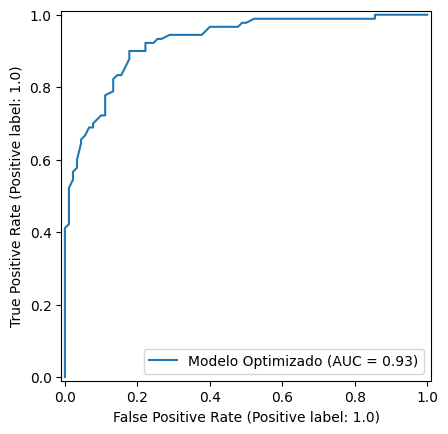

```python
print("Resultados del Modelo Optimizado:")
print(f"Exactitud (Accuracy): {accuracy_optimized:.4f}")
print(f"Sensibilidad (Recall - clase positiva): {sensitivity_optimized:.4f}")
print(f"Especificidad (Recall - clase negativa): {specificity_optimized:.4f}")
print(f"ROC-AUC: {roc_auc_optimized:.4f}")
print("Matriz de Confusión:")
print(conf_matrix_optimized)
print("\nReporte de Clasificación:")
print(classification_report(y_test, y_test_pred))


RocCurveDisplay.from_estimator(
    best_bagging_model, X_test, y_test, name="Modelo Optimizado"
)
```

- 6.4. Análisis de los modelos optimizados

**Análisis:** Valore el impacto de los hiperparámetros optimizados en el conjunto de test comparando con los resultados obtenidos antes de la optimización.

**Comparativa**

[output not shown]

**Resultados**

Adicionalmente es importante remarcar:

**Importancia de la Sensibilidad y la Especificidad en Datos Médicos:**

En el contexto médico, la **sensibilidad** y la **especificidad** son métricas cruciales que miden la capacidad de una prueba diagnóstica para identificar correctamente los casos positivos y negativos, respectivamente. Estas métricas son especialmente importantes porque ayudan a prevenir errores diagnósticos que podrían llevar a tratamientos incorrectos o falta de tratamiento.

- **Sensibilidad** (también conocida como tasa de verdadero positivo): Mide la proporción de positivos reales que son correctamente identificados por el modelo. Una alta sensibilidad es crucial en condiciones médicas donde no detectar una enfermedad (un falso negativo) podría tener consecuencias graves para el paciente. Por ejemplo, en el diagnóstico de cáncer, una alta sensibilidad es esencial para asegurar que casi todos los pacientes con la enfermedad sean identificados para un tratamiento precoz.
- **Especificidad** (también conocida como tasa de verdadero negativo): Mide la proporción de negativos reales que son correctamente identificados. Una alta especificidad es importante para evitar falsos positivos, que podrían llevar a pacientes sin la enfermedad a someterse a procedimientos invasivos o estresantes innecesarios. Por ejemplo, en el cribado de enfermedades cardíacas, una alta especificidad reduce el número de pacientes que recibirán diagnósticos erróneos de condiciones que no tienen.

**Relación entre Sensibilidad y Especificidad:**

La relación entre sensibilidad y especificidad a menudo involucra un **compromiso**; optimizar un modelo para mejorar la sensibilidad generalmente reducirá su especificidad y viceversa. Esto se debe a que el aumento de la sensibilidad implica bajar el umbral para clasificar un resultado como positivo, lo que incrementa el número de falsos positivos y disminuye la especificidad. A la inversa, aumentar la especificidad solo aumenta el umbral, lo que puede llevar a más falsos negativos y disminuir la sensibilidad.

**Aplicaciones en el Mundo Real:**

La selección de un modelo en un entorno médico depende de la enfermedad específica y del contexto del cribado o diagnóstico. En enfermedades donde las consecuencias de no detectar un caso positivo son graves, como en el cáncer o infecciones graves, se puede preferir un modelo con alta sensibilidad. En cambio, en condiciones donde un diagnóstico falso positivo podría llevar a tratamientos innecesarios o perjudiciales, se preferirá un modelo con alta especificidad.

La comprensión de este equilibrio y su correcta aplicación son esenciales para desarrollar herramientas diagnósticas que no solo sean técnicamente competentes sino también éticamente responsables, asegurando que los pacientes reciban el diagnóstico más preciso posible con las mínimas repercusiones negativas.

```python
!pip install nbconvert
from google.colab import files
!jupyter nbconvert --to html "/content/drive/MyDrive/Aprendizaje Automático/Aprendizaje-Automatico/PEC4/M2.891_20241_PEC4-Marina.ipynb"
files.download("/content/drive/MyDrive/Aprendizaje Automático/Aprendizaje-Automatico/PEC4/M2.891_20241_PEC4-Marina.html")
```

```
[NbConvertApp] Converting notebook /content/drive/MyDrive/Aprendizaje Automático/Aprendizaje-Automatico/PEC4/M2.891_20241_PEC4-Marina.ipynb to html
[NbConvertApp] WARNING | Alternative text is missing on 27 image(s).
[NbConvertApp] Writing 3467425 bytes to /content/drive/MyDrive/Aprendizaje Automático/Aprendizaje-Automatico/PEC4/M2.891_20241_PEC4-Marina.html
```